# Análisis Exploratorio de los Datos RECURSOS SANITARIOS: Facilities

Alicia Perdices Guerra

21 de mayo, 2021

- **1.ANÁLISIS EXPLORATORIO POR PAISES.**
  - 1.1 EN RELACIÓN CON LOS RECURSOS SANITARIOS
    - 1.1.1 Análisis Descriptivo
    - 1.1.2 Visualización y Distribución de la variable “Value”
      - Facilities
    - 1.1.3 Normalidad de la variable “Value”
      - Facilities

#### **1.ANÁLISIS EXPLORATORIO POR PAISES**

Se procede en primer lugar a cargar todos los archivos para poder realizar el análisis.

```r
recursos_tec<-read.csv("C:/temp/RecursosTecnicos_hospitalarios_clean.csv",sep= ",")
tecnologia<-read.csv("C:/temp/TecnologiaMedica_clean.csv",sep= ",")
camas_t<-read.csv("C:/temp/TiposCamasHospitalarias_clean.csv",sep= ",")
```

**1.1.- EN RELACIÓN CON LOS RECURSOS SANITARIOS**

- **1.1.1 Análisis Descriptivo**

Se procede a realizar el análisis descriptivo:

```r
summary(recursos_tec)
```

```
##       TIME            GEO                                 FACILITY
##  Min.   :2010   Austria :  60   Day care places altogether    :310
##  1st Qu.:2012   Belgium :  60   Geriatric day care places     :310
##  Median :2014   Bulgaria:  60   Oncological day care place    :310
##  Mean   :2014   Croatia :  60   Operation theatres in hospital:310
##  3rd Qu.:2017   Cyprus  :  60   Psychiatric day care place    :310
##  Max.   :2019   Czechia :  60   Surgical day care places      :310
##                 (Other) :1500
##      UNIT          Value       Value_imp
##  Number:1860   Min.   :    0   Mode :logical
##                1st Qu.:  313   FALSE:830
##                Median : 1133   TRUE :1030
##                Mean   : 2700
##                3rd Qu.: 2341
##                Max.   :77297
##
```

```r
summary(tecnologia)
```

```
##       TIME            GEO                                      UNIT
##  Min.   :2010   Albania :  450   Inhabitants per ...             :5250
##  1st Qu.:2012   Austria :  450   Number                          :5250
##  Median :2014   Belgium :  450   Per hundred thousand inhabitants:5250
##  Mean   :2014   Bulgaria:  450
##  3rd Qu.:2017   Croatia :  450
##  Max.   :2019   Cyprus  :  450
##                 (Other) :13050
##                              FACILITY
##  Angiography units               :3150
##  Computed Tomography Scanners    :3150
##  Gamma cameras                   :3150
##  Lithotriptors                   :3150
##  Magnetic Resonance Imaging Units:3150
##
##
##                                               ICHA_HP         Value
##  Hospitals                                        :5250   Min.   :       0
##  Hospitals and providers of ambulatory health care:5250   1st Qu.:       1
##  Providers of ambulatory health care              :5250   Median :      24
##                                                           Mean   :  205383
##                                                           3rd Qu.:   85973
##                                                           Max.   :46773054
##
##  Value_imp
##  Mode :logical
##  FALSE:8745
##  TRUE :7005
##
##
##
##
```

```r
summary(camas_t)
```

```
##       TIME            GEO                                     UNIT
##  Min.   :2010   Albania : 150   Inhabitants per ...             :1950
##  1st Qu.:2012   Austria : 150   Number                          :1950
##  Median :2014   Belgium : 150   Per hundred thousand inhabitants:1950
##  Mean   :2014   Bulgaria: 150
##  3rd Qu.:2017   Croatia : 150
##  Max.   :2019   Cyprus  : 150
##                 (Other) :4950
##                                          FACILITY        Value
##  Available beds in hospitals (HP.1)          :1170   Min.   :      0.0
##  Curative care beds in hospitals (HP.1)      :1170   1st Qu.:    127.8
##  Long-term care beds in hospitals (HP.1)     :1170   Median :    460.3
##  Other beds in hospitals (HP.1)              :1170   Mean   :  31582.1
##  Rehabilitative care beds in hospitals (HP.1):1170   3rd Qu.:   5023.0
##                                                      Max.   :2711756.0
##
##  Value_imp
##  Mode :logical
##  FALSE:4246
##  TRUE :1604
##
##
##
##
```

Se filta el dataframe para que la variable GEO aparezcan solo los paises objeto de estudio.(Para cada archivo relacionado con los Recursos Sanitarios (Facilities) y unificamos la información en una variable, recursos). Además se selecciona la información relevante de las variables FACILITY,ICHA_HP(Lugar de uso del recurso tecnológico) y UNIT (Se selecciona “Number” y no ratio ya que no todos los archivos tienen la información de número de recursos tecnológicos por 100000 habitantes)

```r
#En relación con las Facilities
#==============================

#Recursos Tecnológicos
#========================
recursos_tec_paises<-filter(recursos_tec,(GEO!="European Union - 27 countries (from 2020)")&
                            +(GEO!="European Union - 28 countries (2013-2020)")&
                            +(GEO!="European Union - 27 countries (2007-2013)")&
                            +(GEO!="European Union - 15 countries (1995-2004)")&
                            +(GEO!="Euro area - 12 countries (2001-2006)")&
                            +(GEO!="Euro area - 19 countries  (from 2015)")&
                            +(GEO!="Euro area - 18 countries (2014)")&
                            +(GEO!="Euro area - 12 countries (2001-2006)"))

#Se selecciona todo lo relacionado con el tipo
#de recurso tecnológico de la variable FACILITY.
recursos_tec_paises_ot<-
  filter(recursos_tec_paises,FACILITY=="Operation theatres in hospital")


recursos_tec_paises_s<-
  filter(recursos_tec_paises,FACILITY=="Surgical day care places")


recursos_tec_paises_p<-
  filter(recursos_tec_paises,FACILITY=="Psychiatric day care place")


recursos_tec_paises_o<-
  filter(recursos_tec_paises,FACILITY=="Oncological day care place")


recursos_tec_paises_g<-
  filter(recursos_tec_paises,FACILITY=="Geriatric day care places")


#Tecnología Médica
#========================
tecnologia_paises<-filter(tecnologia,(GEO!="European Union - 27 countries (from 2020)")&
                            +(GEO!="European Union - 28 countries (2013-2020)")&
                            +(GEO!="European Union - 27 countries (2007-2013)")&
                            +(GEO!="European Union - 15 countries (1995-2004)")&
                            +(GEO!="Euro area - 12 countries (2001-2006)")&
                            +(GEO!="Euro area - 19 countries  (from 2015)")&
                            +(GEO!="Euro area - 18 countries (2014)")&
                            +(GEO!="Euro area - 12 countries (2001-2006)"))

#Se selecciona todo lo relacionado con el tipo
#de tecnología médica de la variable FACILITY.
tecnologia_paises_cts<-
  filter(tecnologia_paises,FACILITY=="Computed Tomography Scanners")


tecnologia_paises_gc<-
  filter(tecnologia_paises,FACILITY=="Gamma cameras")


tecnologia_paises_l<-
  filter(tecnologia_paises,FACILITY=="Lithotriptors")


tecnologia_paises_mr<-
  filter(tecnologia_paises,FACILITY=="Magnetic Resonance Imaging Units")


tecnologia_paises_a<-
  filter(tecnologia_paises,FACILITY=="Angiography units")


tecnologia_paises_cts<-filter(tecnologia_paises_cts,UNIT=="Number")
tecnologia_paises_cts<-filter(tecnologia_paises_cts,ICHA_HP=="Hospitals and providers of ambulatory health care")
tecnologia_paises_gc<-filter(tecnologia_paises_gc,UNIT=="Number")
tecnologia_paises_gc<-filter(tecnologia_paises_gc,ICHA_HP=="Hospitals and providers of ambulatory health care")
tecnologia_paises_l<-filter(tecnologia_paises_l,UNIT=="Number")
tecnologia_paises_l<-filter(tecnologia_paises_l,ICHA_HP=="Hospitals and providers of ambulatory health care")
tecnologia_paises_mr<-filter(tecnologia_paises_mr,UNIT=="Number")
tecnologia_paises_mr<-filter(tecnologia_paises_mr,ICHA_HP=="Hospitals and providers of ambulatory health care")
tecnologia_paises_a<-filter(tecnologia_paises_a,UNIT=="Number")
tecnologia_paises_a<-filter(tecnologia_paises_a,ICHA_HP=="Hospitals and providers of ambulatory health care")



#Camas Disponibles
#========================
camas_t_paises<-filter(camas_t,(GEO!="European Union - 27 countries (from 2020)")&
                            +(GEO!="European Union - 28 countries (2013-2020)")&
                            +(GEO!="European Union - 27 countries (2007-2013)")&
                            +(GEO!="European Union - 15 countries (1995-2004)")&
                            +(GEO!="Euro area - 12 countries (2001-2006)")&
                            +(GEO!="Euro area - 19 countries  (from 2015)")&
                            +(GEO!="Euro area - 18 countries (2014)")&
                            +(GEO!="Euro area - 12 countries (2001-2006)"))

#Se selecciona todo lo relacionado con el tipo
#de camas en hospitales de la variable FACILITY.
camas_t_paises_ca<-
  filter(camas_t_paises,FACILITY=="Available beds in hospitals (HP.1)")


# Se selecciona la unidad: "Number"
camas_t_paises_ca<-filter(camas_t_paises_ca,UNIT=="Number")
nrow(camas_t_paises_ca)
```

```
## [1] 370
```

Tenemos 3 Dataframes (No se unifican debido a la estructura de cada uno (Diferentes filas):

```r
#Recursos Tecnologicos
#=====================
year<-(recursos_tec_paises_ot$TIME)#Columna Year
GEO<-(recursos_tec_paises_ot$GEO)#Columna Paises
recursos_tec_df=data.frame("TIME"=year,"Pais"=GEO,
                     "Operation_theatres_in_hospital"=
                       recursos_tec_paises_ot$Value,
                     "Surgical_day_care_places"=
                       recursos_tec_paises_s$Value,
                     "Psychiatric_day_care_place"=
                       recursos_tec_paises_p$Value,
                     "Oncological_day_care_place"=
                       recursos_tec_paises_o$Value,
                     "Geriatric_day_care_places"=
                       recursos_tec_paises_g$Value)
head(recursos_tec_df)
```

```
##   TIME                                             Pais
## 1 2010                                          Belgium
## 2 2010                                         Bulgaria
## 3 2010                                          Czechia
## 4 2010                                          Denmark
## 5 2010 Germany (until 1990 former territory of the FRG)
## 6 2010                                          Estonia
##   Operation_theatres_in_hospital Surgical_day_care_places
## 1                           1220                     2039
## 2                           1220                     2039
## 3                            996                      996
## 4                           1220                     2039
## 5                           1220                       47
## 6                            132                      349
##   Psychiatric_day_care_place Oncological_day_care_place
## 1                       2279                       1362
## 2                        917                       1362
## 3                       2279                        996
## 4                       3068                       1362
## 5                      15496                        910
## 6                       2279                        910
##   Geriatric_day_care_places
## 1                       568
## 2                      1839
## 3                       996
## 4                      1839
## 5                      1839
## 6                       568
```

```r
#Tecnología Médica
#=================
year<-(tecnologia_paises_cts$TIME)#Columna Year
GEO<-(tecnologia_paises_cts$GEO)#Columna Paises
tecnologia_medica_df=data.frame("TIME"=year,"Pais"=GEO,
                     "Computed_Tomography_Scanners"=
                       tecnologia_paises_cts$Value,
                     "Gamma_cameras"=
                       tecnologia_paises_gc$Value,
                     "Lithotriptors"=
                       tecnologia_paises_l$Value,
                     "Magnetic_Resonance_Imaging_Units"=
                       tecnologia_paises_mr$Value,
                     "Angiography_units"=
                      tecnologia_paises_a$Value)
head(tecnologia_medica_df)
```

```
##   TIME                                             Pais
## 1 2010                                          Belgium
## 2 2010                                         Bulgaria
## 3 2010                                          Czechia
## 4 2010                                          Denmark
## 5 2010 Germany (until 1990 former territory of the FRG)
## 6 2010                                          Estonia
##   Computed_Tomography_Scanners Gamma_cameras Lithotriptors
## 1                          152           152           116
## 2                          224            20            66
## 3                          152           122            32
## 4                          153            94            32
## 5                         2643           122          2211
## 6                           21             3             3
##   Magnetic_Resonance_Imaging_Units Angiography_units
## 1                              116               133
## 2                               31                73
## 3                               66                79
## 4                               66                79
## 5                             2211              2211
## 6                               11                 8
```

```r
#Camas Disponibles
#=================
camas_disponibles_df=camas_t_paises_ca
head(camas_disponibles_df)
```

```
##   TIME                                              GEO   UNIT
## 1 2010                                          Belgium Number
## 2 2010                                         Bulgaria Number
## 3 2010                                          Czechia Number
## 4 2010                                          Denmark Number
## 5 2010 Germany (until 1990 former territory of the FRG) Number
## 6 2010                                          Estonia Number
##                             FACILITY  Value Value_imp
## 1 Available beds in hospitals (HP.1)  66645     FALSE
## 2 Available beds in hospitals (HP.1)  48934     FALSE
## 3 Available beds in hospitals (HP.1)  76413     FALSE
## 4 Available beds in hospitals (HP.1)  19405     FALSE
## 5 Available beds in hospitals (HP.1) 674473     FALSE
## 6 Available beds in hospitals (HP.1)   7022     FALSE
```

```r
#Generamos los ficheros filtrados para utilizarlos en el siguiente análisis.
write.csv(recursos_tec_df, file="Recursos_Tecnologicos_Analisis.csv", row.names = FALSE)
write.csv(tecnologia_medica_df,
          file="Tecnologia_Medica_Analisis.csv", row.names = FALSE)
write.csv(camas_disponibles_df,
          file="Camas_Disponibles_Analisis.csv", row.names = FALSE)
```

Se reescalan los datos:

```r
#Recursos Tecnológicos
#=====================
recursos_tec_df["Operation_theatres_in_hospital_norm"]<-
  rescale(recursos_tec_paises_ot$Value, to=c(0,1))
recursos_tec_df["Surgical_day_care_places_norm"]<-
  rescale(recursos_tec_paises_s$Value, to=c(0,1))
recursos_tec_df["Psychiatric_day_care_place_norm"]<-
  rescale(recursos_tec_paises_p$Value, to=c(0,1))
recursos_tec_df["Oncological_day_care_place_norm"]<-
  rescale(recursos_tec_paises_o$Value, to=c(0,1))
recursos_tec_df["Geriatric_day_care_places_norm"]<-
  rescale(recursos_tec_paises_g$Value, to=c(0,1))

#Tecnología Médica
#=================
tecnologia_medica_df["Computed_Tomography_Scanners_norm"]<-
  rescale(tecnologia_paises_cts$Value, to=c(0,1))
tecnologia_medica_df["Gamma_cameras_norm"]<-
  rescale(tecnologia_paises_gc$Value, to=c(0,1))
tecnologia_medica_df["Lithotriptors_norm"]<-
  rescale(tecnologia_paises_l$Value, to=c(0,1))
tecnologia_medica_df["Magnetic_Resonance_Imaging_Units_norm"]<-
  rescale(tecnologia_paises_mr$Value, to=c(0,1))
tecnologia_medica_df["Angiography_units_norm"]<-
  rescale(tecnologia_paises_a$Value, to=c(0,1))

#Camas Disponibles
#=================
camas_disponibles_df["Value_norm"]<-
    rescale(camas_disponibles_df$Value, to=c(0,1))
```

- **1.1.2 Visualización y Distribución de la variable “Value”**

Se visualiza la variable “Value” en función de TIME, y los distintos tipos de Facilities Sanitarias.

```r
#Recursos Sanitarios (Facilities)_ Recursos Sanitarios
#======================================================

#GRÁFICAS DE BARRAS
#==================
#Gráfica de barras del número de Quirófanos."
plot1=ggplot(data=recursos_tec_df)+
  geom_col(aes(x=TIME,y=Operation_theatres_in_hospital))+
  theme(axis.text.x = element_text(angle = 45))+
  scale_y_continuous(limit=c(0,100000))+
  ggtitle("Quirófanos")+
  theme (plot.title = element_text(size=rel(0.5), hjust = 0.5))

#Gráfica de barras del número de salas de Cirugía hospitalaria diaria
#por Años"
plot2=ggplot(data=recursos_tec_df)+
  geom_col(aes(x=TIME,y=Surgical_day_care_places))+
  theme(axis.text.x = element_text(size= 5,angle = 30,vjust=1,hjust = 1))+
  scale_y_continuous(limit=c(0,100000))+
  ggtitle("Cirugía \n Hospitalaria diaria")+
  theme (plot.title = element_text(size=rel(0.5),hjust = 0.5))

#Gráfica de barras del número de Consultas de Psiquiatría por Años"
plot3=ggplot(data=recursos_tec_df)+
  geom_col(aes(x=TIME,y=Psychiatric_day_care_place))+
  theme(axis.text.x = element_text(size= 5,angle = 30,vjust=1,hjust = 1))+
  scale_y_continuous(limit=c(0,200000))+
  ggtitle("S.Consultas \n Psiquiatría")+
  theme (plot.title = element_text(size=rel(0.5),hjust = 0.5))

#Gráfica de barras del número de Salas de consultas Oncológicas
#por Años.
plot4=ggplot(data=recursos_tec_df)+
  geom_col(aes(x=TIME,y=Oncological_day_care_place))+
  theme(axis.text.x = element_text(size= 5,angle = 30,vjust=1,hjust = 1))+
  scale_y_continuous(limit=c(0,300000))+
  ggtitle("S. Consultas \n Oncología")+
  theme (plot.title = element_text(size=rel(0.5),hjust = 0.5))

#Gráfica de barras del número de Salas de Cuidados Geriátricos
#por Años
plot5=ggplot(data=recursos_tec_df)+
  geom_col(aes(x=TIME,y=Geriatric_day_care_places))+
  theme(axis.text.x = element_text(size= 5,angle = 30,vjust=1,hjust = 1))+
  scale_y_continuous(limit=c(0,100000))+
  ggtitle("S.Cuidados \n Geriátricos")+
  theme (plot.title = element_text(size=rel(0.5),hjust = 0.5))

#Gráfica de barras del número de Escáners (Tomógrafos)
plot6=ggplot(data=tecnologia_medica_df)+
  geom_col(aes(x=TIME,y=Computed_Tomography_Scanners))+
  theme(axis.text.x = element_text(size= 5,angle = 30,vjust=1,hjust = 1))+
  scale_y_continuous(limit=c(0,100000))+
  ggtitle("Escáners \n Tomógrafos")+
  theme (plot.title = element_text(size=rel(0.5),hjust = 0.5))

#Gráfica de barras del número de Cámaras Gamma
plot7=ggplot(data=tecnologia_medica_df)+
  geom_col(aes(x=TIME,y=Gamma_cameras))+
  theme(axis.text.x = element_text(size= 5,angle = 30,vjust=1,hjust = 1))+
  scale_y_continuous(limit=c(0,100000))+
  ggtitle("Cámaras\n Gamma")+
  theme (plot.title = element_text(size=rel(0.5),hjust = 0.5))

#Gráfica de barras del número Litotriptores
plot8=ggplot(data=tecnologia_medica_df)+
  geom_col(aes(x=TIME,y=Lithotriptors))+
  theme(axis.text.x = element_text(size= 5,angle = 30,vjust=1,hjust = 1))+
  scale_y_continuous(limit=c(0,100000))+
  ggtitle("Litotriptores")+
  theme (plot.title = element_text(size=rel(0.5),hjust = 0.5))

#Gráfica de barras del número de Unidades de Resonancia Magnética
plot9=ggplot(data=tecnologia_medica_df)+
  geom_col(aes(x=TIME,y=Magnetic_Resonance_Imaging_Units))+
  theme(axis.text.x = element_text(size= 5,angle = 30,vjust=1,hjust = 1))+
  scale_y_continuous(limit=c(0,100000))+
  ggtitle("Resonancia \n Magnética")+
  theme (plot.title = element_text(size=rel(0.5),hjust = 0.5))

#Gráfica de barras del número de Unidades de Angiógrafía
plot10=ggplot(data=tecnologia_medica_df)+
  geom_col(aes(x=TIME,y=Angiography_units))+
  theme(axis.text.x = element_text(size= 5,angle = 30,vjust=1,hjust = 1))+
  scale_y_continuous(limit=c(0,100000))+
  ggtitle("Unidades \n Angiógrafía")+
  theme (plot.title = element_text(size=rel(0.5),hjust = 0.5))

#Gráfica de barras del número de Camas Hospitalarias Disponibles.
plot11=ggplot(data=camas_disponibles_df)+
  geom_col(aes(x=TIME,y=Value))+
  theme(axis.text.x = element_text(size= 5,angle = 30,vjust=1,hjust = 1))+
  scale_y_continuous(limit=c(0,4000000))+
  ggtitle("Camas \n Disponibles")+
  theme (plot.title = element_text(size=rel(0.5),hjust = 0.5))
```

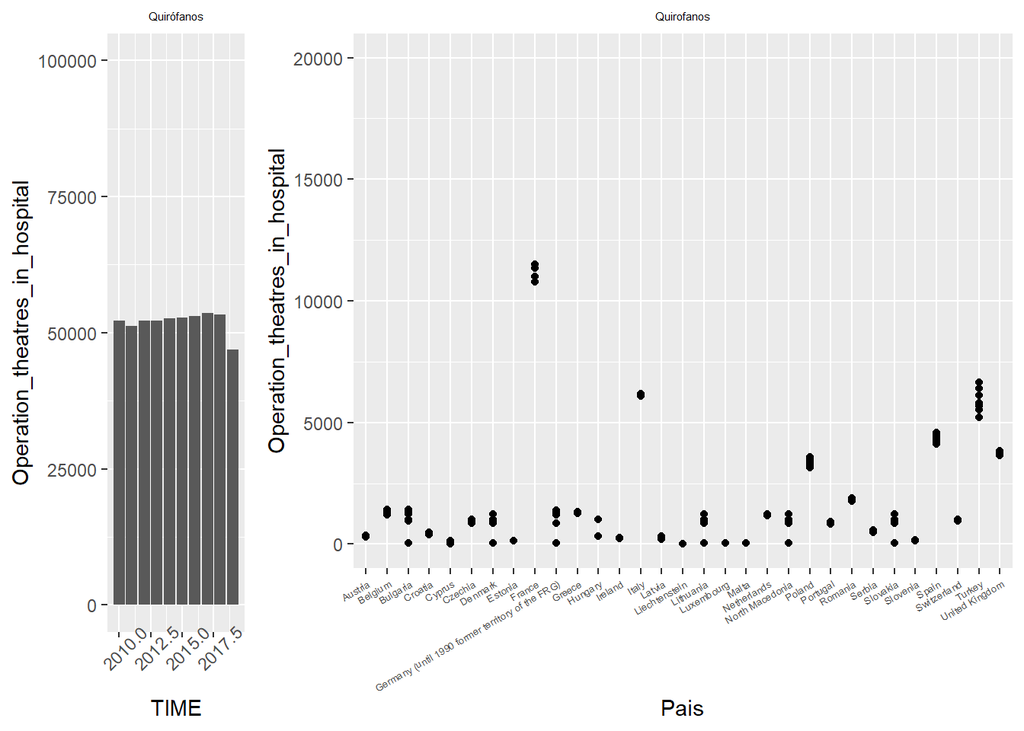

```r
#GRÁFICAS DE PUNTOS
#==================
##Gráfica de puntos del número de Quirófanos por Países.""
plot12=ggplot(data=recursos_tec_df)+
  geom_point(aes(x=Pais,y=Operation_theatres_in_hospital))+
  theme(axis.text.x = element_text(size= 5,angle = 30,vjust=1,hjust = 1))+
  scale_y_continuous(limit=c(0,20000))+
  ggtitle("Quirofanos")+
  theme (plot.title = element_text(size=rel(0.5),hjust=0.5))

#Gráfica de puntos del número del número de salas de Cirugía hospitalaria diaria
#por Países"  "
plot13=ggplot(data=recursos_tec_df)+
  geom_point(aes(x=Pais,y=Surgical_day_care_places))+
  theme(axis.text.x = element_text(size= 5,angle = 30,vjust=1,hjust = 1))+
  scale_y_continuous(limit=c(0,20000))+
  ggtitle("S.Cirugía \n Hospitalaria Diaria")+
  theme (plot.title = element_text(size=rel(0.5),hjust = 0.5))

#Gráfica de puntos del número Consultas de Psiquiatría por Países"
plot14=ggplot(data=recursos_tec_df)+
  geom_point(aes(x=Pais,y=Psychiatric_day_care_place))+
  theme(axis.text.x = element_text(size= 5,angle = 30,vjust=1,hjust = 1))+
  scale_y_continuous(limit=c(0,30000))+
  ggtitle("S.Consulta \n Psiquiatría")+
  theme (plot.title = element_text(size=rel(0.5),hjust = 0.5))

#Gráfica de puntos del número de Salas de consultas Oncológicas
#por Países.
plot15=ggplot(data=recursos_tec_df)+
  geom_point(aes(x=Pais,y=Oncological_day_care_place))+
  theme(axis.text.x = element_text(size= 5,angle = 30,vjust=1,hjust = 1))+
  scale_y_continuous(limit=c(0,20000))+
  ggtitle("S.Consultas \n Oncológicas")+
  theme (plot.title = element_text(size=rel(0.5),hjust = 0.5))

#Gráfica de puntos del número de Salas de Cuidados Geriátricos
#por Paises.
plot16=ggplot(data=recursos_tec_df)+
  geom_point(aes(x=Pais,y=Geriatric_day_care_places))+
  theme(axis.text.x = element_text(size= 5,angle = 30,vjust=1,hjust = 1))+
  scale_y_continuous(limit=c(0,20000))+
  ggtitle("S.Cuidados \n Geriátricos")+
  theme (plot.title = element_text(size=rel(0.5),hjust = 0.5))

#Gráfica de puntos del número de Escáners (Tomógrafos) por Países.
plot17=ggplot(data=tecnologia_medica_df)+
  geom_point(aes(x=Pais,y=Computed_Tomography_Scanners))+
  theme(axis.text.x = element_text(size= 5,angle = 30,vjust=1,hjust = 1))+
  scale_y_continuous(limit=c(0,20000))+
  ggtitle("Escáners")+
  theme (plot.title = element_text(size=rel(0.5),hjust = 0.5))

#Gráfica de puntos del número de Cámaras Gamma por Países.
plot18=ggplot(data=tecnologia_medica_df)+
  geom_point(aes(x=Pais,y=Gamma_cameras))+
  theme(axis.text.x = element_text(size= 5,angle = 30,vjust=1,hjust = 1))+
  scale_y_continuous(limit=c(0,20000))+
  ggtitle("Cámaras Gamma")+
  theme (plot.title = element_text(size=rel(0.5),hjust = 0.5))

#Gráfica de puntos del número Litotriptores y Países
plot19=ggplot(data=tecnologia_medica_df)+
  geom_point(aes(x=Pais,y=Lithotriptors))+
  theme(axis.text.x = element_text(size= 5,angle = 30,vjust=1,hjust = 1))+
  scale_y_continuous(limit=c(0,20000))+
  ggtitle("Litotriptores")+
  theme (plot.title = element_text(size=rel(0.5),hjust = 0.5))

#Gráfica de puntos del número de Unidades de Resonancia Magnética
plot20=ggplot(data=tecnologia_medica_df)+
  geom_point(aes(x=Pais,y=Magnetic_Resonance_Imaging_Units))+
  theme(axis.text.x = element_text(size= 5,angle = 30,vjust=1,hjust = 1))+
  scale_y_continuous(limit=c(0,20000))+
  ggtitle("Unidades\n R.Magnética")+
  theme (plot.title = element_text(size=rel(0.5),hjust = 0.5))

#Gráfica de puntos del número de Unidades de Angiógrafía y Países
plot21=ggplot(data=tecnologia_medica_df)+
  geom_point(aes(x=Pais,y=Angiography_units))+
  theme(axis.text.x = element_text(size= 5,angle = 30,vjust=1,hjust = 1))+
  scale_y_continuous(limit=c(0,20000))+
  ggtitle("Unidades\n Angiografía")+
  theme (plot.title = element_text(size=rel(0.5),hjust = 0.5))

#Gráfica de puntos del número de Camas Hospitalarias Disponibles y Países
plot22=ggplot(data=camas_disponibles_df)+
  geom_point(aes(x=GEO,y=Value))+
  theme(axis.text.x = element_text(size= 5,angle = 30,vjust=1,hjust = 1))+
  scale_y_continuous(limit=c(0,1000000))+
  ggtitle("Camas\n Disponibles")+
  theme (plot.title = element_text(size=rel(0.5),hjust = 0.5))

grid.arrange(plot1,plot12,widths=c(1,3), ncol=2)
```

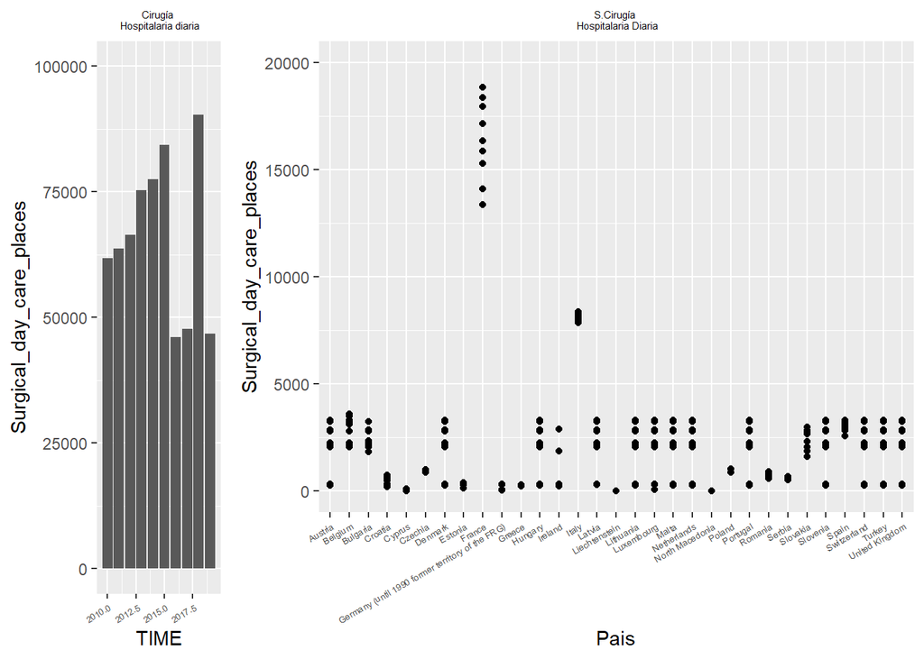

```r
grid.arrange(plot2,plot13,widths=c(1,3), ncol=2)
```

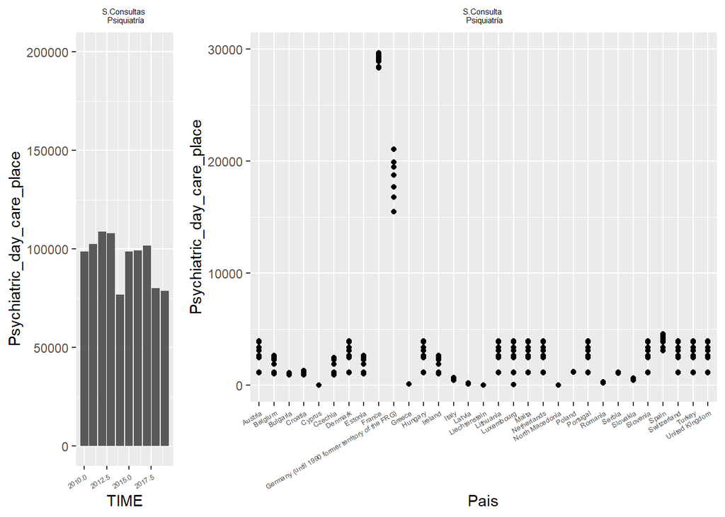

```r
grid.arrange(plot3,plot14,widths=c(1,3), ncol=2)
```

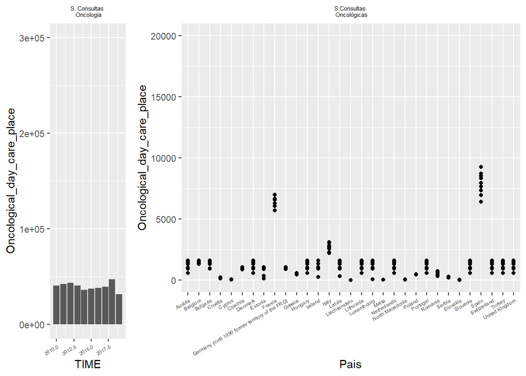

```r
grid.arrange(plot4,plot15,widths=c(1,3), ncol=2)
```

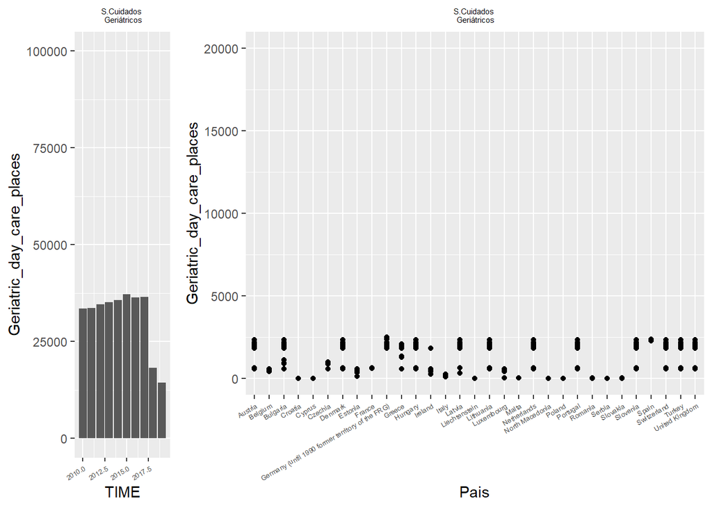

```r
grid.arrange(plot5,plot16,widths=c(1,3), ncol=2)
```

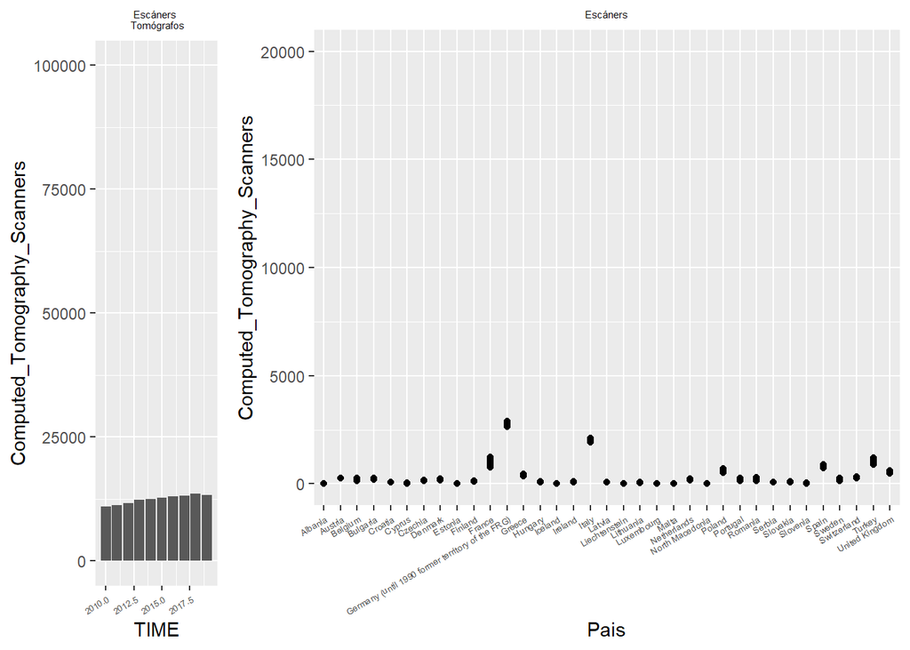

```r
grid.arrange(plot6,plot17,widths=c(1,3), ncol=2)
```

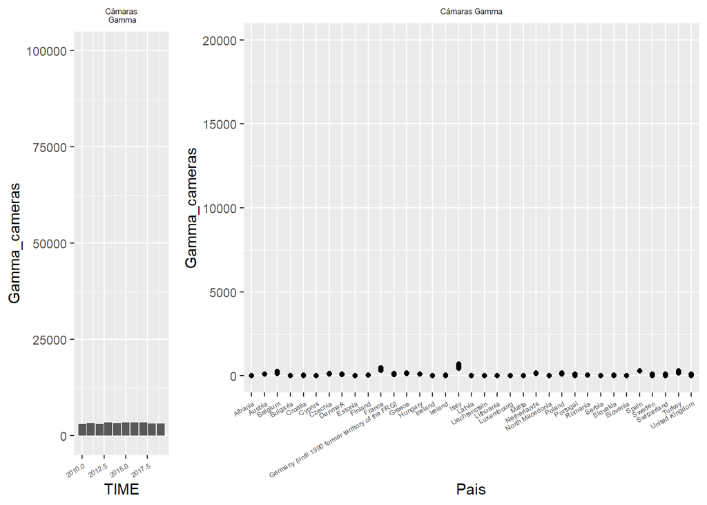

```r
grid.arrange(plot7,plot18,widths=c(1,3), ncol=2)
```

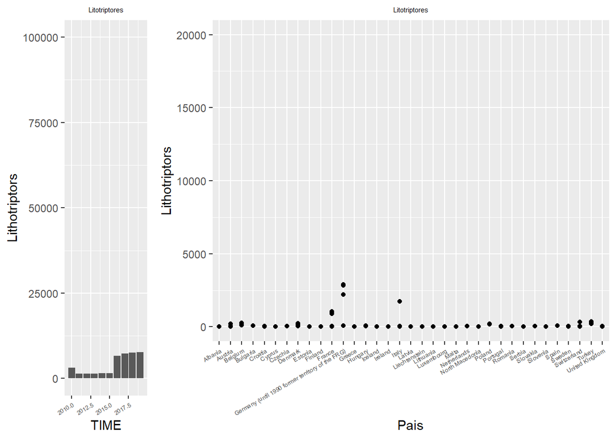

```r
grid.arrange(plot8,plot19,widths=c(1,3), ncol=2)
```

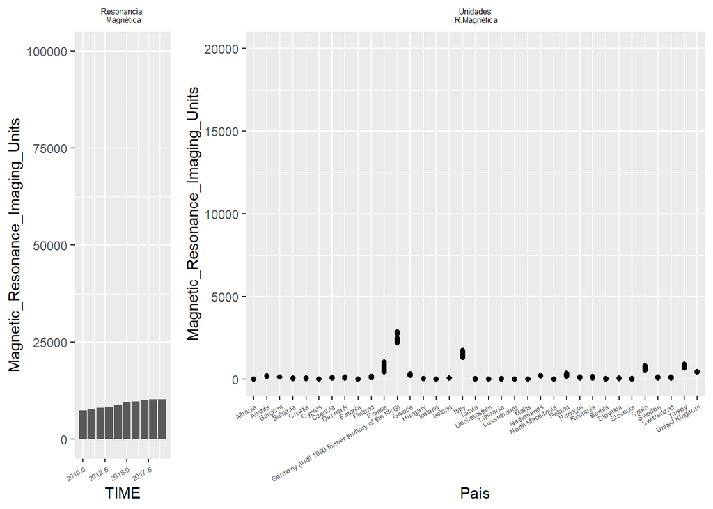

```r
grid.arrange(plot9,plot20,widths=c(1,3), ncol=2)
```

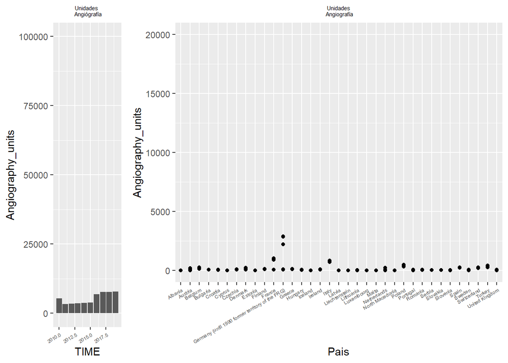

```r
grid.arrange(plot10,plot21,widths=c(1,3), ncol=2)
```

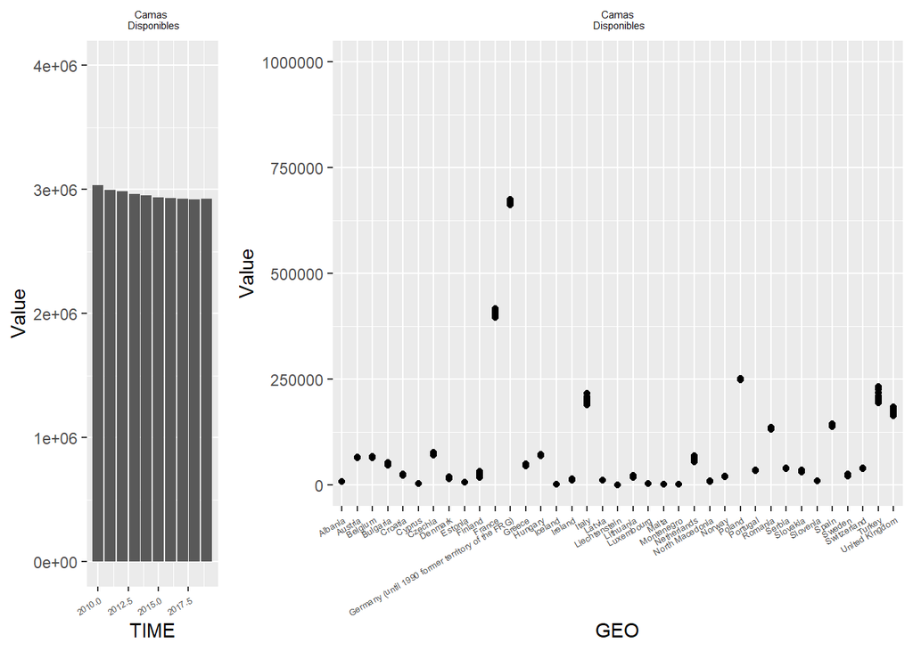

```r
grid.arrange(plot11,plot22,widths=c(1,3), ncol=2)
```

Se obtienen los 5 países con mayor número de Recursos Sanitarios (Facilities), por años y en cómputo global.

- **Operation_theatres_in_hospital**

```r
#########################################
#Para "Operation_theatres_in_hospital"  #
#########################################

#Se filtra por Año
y_2010<-filter(recursos_tec_df, TIME==2010)
y_2011<-filter(recursos_tec_df, TIME==2011)
y_2012<-filter(recursos_tec_df, TIME==2012)
y_2013<-filter(recursos_tec_df, TIME==2013)
y_2014<-filter(recursos_tec_df, TIME==2014)
y_2015<-filter(recursos_tec_df, TIME==2015)
y_2016<-filter(recursos_tec_df, TIME==2016)
y_2017<-filter(recursos_tec_df, TIME==2017)
y_2018<-filter(recursos_tec_df, TIME==2018)
y_2019<-filter(recursos_tec_df, TIME==2019)

#Se ordena por "Operation_theatres_in_hospital"

recursos_tec_5paises_2010<-y_2010[with(y_2010, order(-y_2010$Operation_theatres_in_hospital)),]
recursos_tec_5paises_2011<-y_2011[with(y_2011, order(-y_2011$Operation_theatres_in_hospital)),]
recursos_tec_5paises_2012<-y_2012[with(y_2012, order(-y_2012$Operation_theatres_in_hospital)),]
recursos_tec_5paises_2013<-y_2013[with(y_2013, order(-y_2013$Operation_theatres_in_hospital)),]
recursos_tec_5paises_2014<-y_2014[with(y_2014, order(-y_2014$Operation_theatres_in_hospital)),]
recursos_tec_5paises_2015<-y_2015[with(y_2015, order(-y_2015$Operation_theatres_in_hospital)),]
recursos_tec_5paises_2016<-y_2016[with(y_2016, order(-y_2016$Operation_theatres_in_hospital)),]
recursos_tec_5paises_2017<-y_2017[with(y_2017, order(-y_2017$Operation_theatres_in_hospital)),]
recursos_tec_5paises_2018<-y_2018[with(y_2018, order(-y_2018$Operation_theatres_in_hospital)),]
recursos_tec_5paises_2019<-y_2019[with(y_2019, order(-y_2019$Operation_theatres_in_hospital)),]


#Se crea una tabla para cada año sobre los Recursos Sanitarios
#(Facilities:Quirófanos) de los 5 Paises con un mayor número de Quirófanos.

kable(recursos_tec_5paises_2010[0:5,c(2,3)], col.names = c("País","Quirofanos"),
      caption = "Países con mayor Número de Quirofanos en 2010")
```

Países con mayor Número de Quirofanos en 2010

|  | País | Quirofanos |
| --- | --- | --- |
| 10 | France | 11337 |
| 12 | Italy | 6088 |
| 31 | Turkey | 5206 |
| 9 | Spain | 4120 |
| 28 | United Kingdom | 3739 |

```r
kable(recursos_tec_5paises_2011[0:5,c(2,3)], col.names = c("País","Quirofanos"),
      caption = "Países con mayor Número de Quirofanos en 2011")
```

Países con mayor Número de Quirofanos en 2011

|  | País | Quirofanos |
| --- | --- | --- |
| 10 | France | 11337 |
| 12 | Italy | 6092 |
| 31 | Turkey | 5206 |
| 9 | Spain | 4202 |
| 28 | United Kingdom | 3636 |

```r
kable(recursos_tec_5paises_2012[0:5,c(2,3)], col.names = c("País","Quirofanos"),
      caption = "Países con mayor Número de Quirofanos en 2012")
```

Países con mayor Número de Quirofanos en 2012

|  | País | Quirofanos |
| --- | --- | --- |
| 10 | France | 11337 |
| 12 | Italy | 6118 |
| 31 | Turkey | 5697 |
| 9 | Spain | 4267 |
| 28 | United Kingdom | 3684 |

```r
kable(recursos_tec_5paises_2013[0:5,c(2,3)], col.names = c("País","Quirofanos"),
      caption = "Países con mayor Número de Quirofanos en 2013")
```

Países con mayor Número de Quirofanos en 2013

|  | País | Quirofanos |
| --- | --- | --- |
| 10 | France | 11505 |
| 12 | Italy | 6078 |
| 31 | Turkey | 5526 |
| 9 | Spain | 4307 |
| 28 | United Kingdom | 3776 |

```r
kable(recursos_tec_5paises_2014[0:5,c(2,3)], col.names = c("País","Quirofanos"),
      caption = "Países con mayor Número de Quirofanos en 2014")
```

Países con mayor Número de Quirofanos en 2014

|  | País | Quirofanos |
| --- | --- | --- |
| 10 | France | 11337 |
| 12 | Italy | 6095 |
| 31 | Turkey | 5682 |
| 9 | Spain | 4352 |
| 28 | United Kingdom | 3800 |

```r
kable(recursos_tec_5paises_2015[0:5,c(2,3)], col.names = c("País","Quirofanos"),
      caption = "Países con mayor Número de Quirofanos en 2015")
```

Países con mayor Número de Quirofanos en 2015

|  | País | Quirofanos |
| --- | --- | --- |
| 10 | France | 10991 |
| 12 | Italy | 6173 |
| 31 | Turkey | 5809 |
| 9 | Spain | 4421 |
| 28 | United Kingdom | 3824 |

```r
kable(recursos_tec_5paises_2016[0:5,c(2,3)], col.names = c("País","Quirofanos"),
      caption = "Países con mayor Número de Quirofanos en 2016")
```

Países con mayor Número de Quirofanos en 2016

|  | País | Quirofanos |
| --- | --- | --- |
| 10 | France | 10788 |
| 12 | Italy | 6139 |
| 31 | Turkey | 6126 |
| 9 | Spain | 4448 |
| 28 | United Kingdom | 3826 |

```r
kable(recursos_tec_5paises_2017[0:5,c(2,3)], col.names = c("País","Quirofanos"),
      caption = "Países con mayor Número de Quirofanos en 2017")
```

Países con mayor Número de Quirofanos en 2017

|  | País | Quirofanos |
| --- | --- | --- |
| 10 | France | 10774 |
| 31 | Turkey | 6403 |
| 12 | Italy | 6191 |
| 9 | Spain | 4533 |
| 28 | United Kingdom | 3824 |

```r
kable(recursos_tec_5paises_2018[0:5,c(2,3)], col.names = c("País","Quirofanos"),
      caption = "Países con mayor Número de Quirofanos en 2018")
```

Países con mayor Número de Quirofanos en 2018

|  | País | Quirofanos |
| --- | --- | --- |
| 10 | France | 10777 |
| 31 | Turkey | 6658 |
| 12 | Italy | 6164 |
| 9 | Spain | 4573 |
| 28 | United Kingdom | 3824 |

```r
kable(recursos_tec_5paises_2019[0:5,c(2,3)], col.names = c("País","Quirofanos"),
      caption = "Países con mayor Número de Quirofanos en 2019")
```

Países con mayor Número de Quirofanos en 2019

|  | País | Quirofanos |
| --- | --- | --- |
| 10 | France | 10777 |
| 31 | Turkey | 6403 |
| 12 | Italy | 6164 |
| 9 | Spain | 4533 |
| 28 | United Kingdom | 3824 |

A continuación, se aprupa toda la información (Quirófanos) por paises en una tabla:

```r
a1<-group_by(recursos_tec_df,Pais)#Se agrupa por paises
#Se selecciona las variables Pais y Operation_theatres_in_hospital
a2<-select(a1,Pais:Operation_theatres_in_hospital)
#Se muestra la información por cada país, con Value=suma de
#los valores de cada país en los 10 años.
a3<-(summarize(a2,suma=sum(Operation_theatres_in_hospital)/10))
a4<-data.frame(a3)#Se convierte la información en un dataframe.
#Se ordena el DataFrame por la variable Suma de forma descendente.
a5<-a4[with(a4,order(-a4$suma)),]

#Se crea una tabla con toda la informacion
kable(a5[0:5,c(1,2)],
      col.names = c("País","Quirofanos"),
      caption = "Países con la mayor media Quirófanos en 2010-2019")
```

Países con la mayor media Quirófanos en 2010-2019

|  | País | Quirofanos |
| --- | --- | --- |
| 9 | France | 11096.0 |
| 14 | Italy | 6130.2 |
| 30 | Turkey | 5871.6 |
| 28 | Spain | 4375.6 |
| 31 | United Kingdom | 3775.7 |

- **Surgical_day_care_places**

```r
#########################################
#Para "Surgical_day_care_places"        #
#########################################

#Se filtra por Año
y_2010<-filter(recursos_tec_df, TIME==2010)
y_2011<-filter(recursos_tec_df, TIME==2011)
y_2012<-filter(recursos_tec_df, TIME==2012)
y_2013<-filter(recursos_tec_df, TIME==2013)
y_2014<-filter(recursos_tec_df, TIME==2014)
y_2015<-filter(recursos_tec_df, TIME==2015)
y_2016<-filter(recursos_tec_df, TIME==2016)
y_2017<-filter(recursos_tec_df, TIME==2017)
y_2018<-filter(recursos_tec_df, TIME==2018)
y_2019<-filter(recursos_tec_df, TIME==2019)

#Se ordena por "Surgical_day_care_places"

recursos_tec_5paises_2010<-y_2010[with(y_2010, order(-y_2010$Surgical_day_care_places)),]
recursos_tec_5paises_2011<-y_2011[with(y_2011, order(-y_2011$Surgical_day_care_places)),]
recursos_tec_5paises_2012<-y_2012[with(y_2012, order(-y_2012$Surgical_day_care_places)),]
recursos_tec_5paises_2013<-y_2013[with(y_2013, order(-y_2013$Surgical_day_care_places)),]
recursos_tec_5paises_2014<-y_2014[with(y_2014, order(-y_2014$Surgical_day_care_places)),]
recursos_tec_5paises_2015<-y_2015[with(y_2015, order(-y_2015$Surgical_day_care_places)),]
recursos_tec_5paises_2016<-y_2016[with(y_2016, order(-y_2016$Surgical_day_care_places)),]
recursos_tec_5paises_2017<-y_2017[with(y_2017, order(-y_2017$Surgical_day_care_places)),]
recursos_tec_5paises_2018<-y_2018[with(y_2018, order(-y_2018$Surgical_day_care_places)),]
recursos_tec_5paises_2019<-y_2019[with(y_2019, order(-y_2019$Surgical_day_care_places)),]


#Se crea una tabla para cada año sobre los Recursos Sanitarios
#(Facilities:S. Quirúrgicas) de los 5 Paises con un mayor número de ellas.

kable(recursos_tec_5paises_2010[0:5,c(2,4)], col.names = c("País","S Cirugía"),
      caption = "Países con mayor Número de Salas Quirúrgicas en 2010")
```

Países con mayor Número de Salas Quirúrgicas en 2010

|  | País | S Cirugía |
| --- | --- | --- |
| 10 | France | 13346 |
| 12 | Italy | 7841 |
| 9 | Spain | 2562 |
| 1 | Belgium | 2039 |
| 2 | Bulgaria | 2039 |

```r
kable(recursos_tec_5paises_2011[0:5,c(2,4)], col.names = c("País","S Cirugía"),
      caption = "Países con mayor Número de Salas Quirúrgicas en 2011")
```

Países con mayor Número de Salas Quirúrgicas en 2011

|  | País | S Cirugía |
| --- | --- | --- |
| 10 | France | 14110 |
| 12 | Italy | 8013 |
| 9 | Spain | 2838 |
| 1 | Belgium | 2177 |
| 2 | Bulgaria | 2177 |

```r
kable(recursos_tec_5paises_2012[0:5,c(2,4)], col.names = c("País","S Cirugía"),
      caption = "Países con mayor Número de Salas Quirúrgicas en 2012")
```

Países con mayor Número de Salas Quirúrgicas en 2012

|  | País | S Cirugía |
| --- | --- | --- |
| 10 | France | 15272 |
| 12 | Italy | 8139 |
| 9 | Spain | 3008 |
| 1 | Belgium | 2247 |
| 2 | Bulgaria | 2247 |

```r
kable(recursos_tec_5paises_2013[0:5,c(2,4)], col.names = c("País","S Cirugía"),
      caption = "Países con mayor Número de Salas Quirúrgicas en 2013")
```

Países con mayor Número de Salas Quirúrgicas en 2013

|  | País | S Cirugía |
| --- | --- | --- |
| 10 | France | 15856 |
| 12 | Italy | 8102 |
| 9 | Spain | 2892 |
| 1 | Belgium | 2788 |
| 2 | Bulgaria | 2788 |

```r
kable(recursos_tec_5paises_2014[0:5,c(2,4)], col.names = c("País","S Cirugía"),
      caption = "Países con mayor Número de Salas Quirúrgicas en 2014")
```

Países con mayor Número de Salas Quirúrgicas en 2014

|  | País | S Cirugía |
| --- | --- | --- |
| 10 | France | 16334 |
| 12 | Italy | 7877 |
| 1 | Belgium | 3118 |
| 2 | Bulgaria | 2855 |
| 4 | Denmark | 2855 |

```r
kable(recursos_tec_5paises_2015[0:5,c(2,4)], col.names = c("País","S Cirugía"),
      caption = "Países con mayor Número de Salas Quirúrgicas en 2015")
```

Países con mayor Número de Salas Quirúrgicas en 2015

|  | País | S Cirugía |
| --- | --- | --- |
| 10 | France | 17147 |
| 12 | Italy | 8197 |
| 1 | Belgium | 3243 |
| 2 | Bulgaria | 3225 |
| 4 | Denmark | 3225 |

```r
kable(recursos_tec_5paises_2016[0:5,c(2,4)], col.names = c("País","S Cirugía"),
      caption = "Países con mayor Número de Salas Quirúrgicas en 2016")
```

Países con mayor Número de Salas Quirúrgicas en 2016

|  | País | S Cirugía |
| --- | --- | --- |
| 10 | France | 17953 |
| 12 | Italy | 8234 |
| 1 | Belgium | 3291 |
| 9 | Spain | 3154 |
| 25 | Slovakia | 2775 |

```r
kable(recursos_tec_5paises_2017[0:5,c(2,4)], col.names = c("País","S Cirugía"),
      caption = "Países con mayor Número de Salas Quirúrgicas en 2017")
```

Países con mayor Número de Salas Quirúrgicas en 2017

|  | País | S Cirugía |
| --- | --- | --- |
| 10 | France | 18353 |
| 12 | Italy | 8172 |
| 1 | Belgium | 3479 |
| 9 | Spain | 3207 |
| 25 | Slovakia | 2815 |

```r
kable(recursos_tec_5paises_2018[0:5,c(2,4)], col.names = c("País","S Cirugía"),
      caption = "Países con mayor Número de Salas Quirúrgicas en 2018")
```

Países con mayor Número de Salas Quirúrgicas en 2018

|  | País | S Cirugía |
| --- | --- | --- |
| 10 | France | 18837 |
| 12 | Italy | 8353 |
| 1 | Belgium | 3587 |
| 4 | Denmark | 3309 |
| 9 | Spain | 3309 |

```r
kable(recursos_tec_5paises_2019[0:5,c(2,4)], col.names = c("País","S Cirugía"),
      caption = "Países con mayor Número de Salas Quirúrgicas en 2019")
```

Países con mayor Número de Salas Quirúrgicas en 2019

|  | País | S Cirugía |
| --- | --- | --- |
| 10 | France | 18353 |
| 12 | Italy | 8234 |
| 1 | Belgium | 3479 |
| 9 | Spain | 3207 |
| 25 | Slovakia | 2815 |

A continuación, se aprupa toda la información (Salas Quirúrgicas) por paises en una tabla:

```r
a1<-group_by(recursos_tec_df,Pais)#Se agrupa por paises
#Se selecciona las variables Pais y Surgical_day_care_places
a2<-select(a1,Pais:Surgical_day_care_places)
#Se muestra la información por cada país, con Value=suma de
#los valores de cada país en los 10 años.
a3<-(summarize(a2,suma=sum(Surgical_day_care_places)/10))
a4<-data.frame(a3)#Se convierte la información en un dataframe.
#Se ordena el DataFrame por la variable Suma de forma descendente.
a5<-a4[with(a4,order(-a4$suma)),]

#Se crea una tabla con toda la informacion
kable(a5[0:5,c(1,2)],
      col.names = c("País","S Cirugía"),
      caption = "Países con la mayor media en Salas Quirúrgicas en 2010-2019")
```

Países con la mayor media en Salas Quirúrgicas en 2010-2019

|  | País | S Cirugía |
| --- | --- | --- |
| 9 | France | 16556.1 |
| 14 | Italy | 8116.2 |
| 28 | Spain | 3025.7 |
| 2 | Belgium | 2944.8 |
| 26 | Slovakia | 2462.8 |

- **Psychiatric_day_care_place**

```r
#########################################
#Para "Psychiatric_day_care_place"      #
#########################################

#Se filtra por Año
y_2010<-filter(recursos_tec_df, TIME==2010)
y_2011<-filter(recursos_tec_df, TIME==2011)
y_2012<-filter(recursos_tec_df, TIME==2012)
y_2013<-filter(recursos_tec_df, TIME==2013)
y_2014<-filter(recursos_tec_df, TIME==2014)
y_2015<-filter(recursos_tec_df, TIME==2015)
y_2016<-filter(recursos_tec_df, TIME==2016)
y_2017<-filter(recursos_tec_df, TIME==2017)
y_2018<-filter(recursos_tec_df, TIME==2018)
y_2019<-filter(recursos_tec_df, TIME==2019)

#Se ordena por "Psychiatric_day_care_place"

recursos_tec_5paises_2010<-y_2010[with(y_2010, order(-y_2010$Psychiatric_day_care_place)),]
recursos_tec_5paises_2011<-y_2011[with(y_2011, order(-y_2011$Psychiatric_day_care_place)),]
recursos_tec_5paises_2012<-y_2012[with(y_2012, order(-y_2012$Psychiatric_day_care_place)),]
recursos_tec_5paises_2013<-y_2013[with(y_2013, order(-y_2013$Psychiatric_day_care_place)),]
recursos_tec_5paises_2014<-y_2014[with(y_2014, order(-y_2014$Psychiatric_day_care_place)),]
recursos_tec_5paises_2015<-y_2015[with(y_2015, order(-y_2015$Psychiatric_day_care_place)),]
recursos_tec_5paises_2016<-y_2016[with(y_2016, order(-y_2016$Psychiatric_day_care_place)),]
recursos_tec_5paises_2017<-y_2017[with(y_2017, order(-y_2017$Psychiatric_day_care_place)),]
recursos_tec_5paises_2018<-y_2018[with(y_2018, order(-y_2018$Psychiatric_day_care_place)),]
recursos_tec_5paises_2019<-y_2019[with(y_2019, order(-y_2019$Psychiatric_day_care_place)),]


#Se crea una tabla para cada año sobre los Recursos Sanitarios
#(Facilities:S.Psiquiatría) de los 5 Paises con un mayor número de ellas.

kable(recursos_tec_5paises_2010[0:5,c(2,5)], col.names = c("País","S.Psiquiatría"),
      caption = "Países con mayor Número de Salas de Psiquiatría en 2010")
```

Países con mayor Número de Salas de Psiquiatría en 2010

|  | País | S.Psiquiatría |
| --- | --- | --- |
| 10 | France | 28285 |
| 5 | Germany (until 1990 former territory of the FRG) | 15496 |
| 4 | Denmark | 3068 |
| 9 | Spain | 3068 |
| 15 | Lithuania | 3068 |

```r
kable(recursos_tec_5paises_2011[0:5,c(2,5)], col.names = c("País","S.Psiquiatría"),
      caption = "Países con mayor Número de Salas de Psiquiatría en 2011")
```

Países con mayor Número de Salas de Psiquiatría en 2011

|  | País | S.Psiquiatría |
| --- | --- | --- |
| 10 | France | 28424 |
| 5 | Germany (until 1990 former territory of the FRG) | 15457 |
| 4 | Denmark | 3366 |
| 9 | Spain | 3366 |
| 15 | Lithuania | 3366 |

```r
kable(recursos_tec_5paises_2012[0:5,c(2,5)], col.names = c("País","S.Psiquiatría"),
      caption = "Países con mayor Número de Salas de Psiquiatría en 2012")
```

Países con mayor Número de Salas de Psiquiatría en 2012

|  | País | S.Psiquiatría |
| --- | --- | --- |
| 10 | France | 28871 |
| 5 | Germany (until 1990 former territory of the FRG) | 16773 |
| 4 | Denmark | 3848 |
| 9 | Spain | 3848 |
| 15 | Lithuania | 3848 |

```r
kable(recursos_tec_5paises_2013[0:5,c(2,5)], col.names = c("País","S.Psiquiatría"),
      caption = "Países con mayor Número de Salas de Psiquiatría en 2013")
```

Países con mayor Número de Salas de Psiquiatría en 2013

|  | País | S.Psiquiatría |
| --- | --- | --- |
| 10 | France | 29065 |
| 5 | Germany (until 1990 former territory of the FRG) | 17686 |
| 4 | Denmark | 3942 |
| 9 | Spain | 3942 |
| 15 | Lithuania | 3942 |

```r
kable(recursos_tec_5paises_2014[0:5,c(2,5)], col.names = c("País","S.Psiquiatría"),
      caption = "Países con mayor Número de Salas de Psiquiatría en 2014")
```

Países con mayor Número de Salas de Psiquiatría en 2014

|  | País | S.Psiquiatría |
| --- | --- | --- |
| 10 | France | 29245 |
| 5 | Germany (until 1990 former territory of the FRG) | 18753 |
| 9 | Spain | 4018 |
| 1 | Belgium | 1174 |
| 3 | Czechia | 1174 |

```r
kable(recursos_tec_5paises_2015[0:5,c(2,5)], col.names = c("País","S.Psiquiatría"),
      caption = "Países con mayor Número de Salas de Psiquiatría en 2015")
```

Países con mayor Número de Salas de Psiquiatría en 2015

|  | País | S.Psiquiatría |
| --- | --- | --- |
| 10 | France | 29357 |
| 5 | Germany (until 1990 former territory of the FRG) | 19464 |
| 9 | Spain | 4171 |
| 1 | Belgium | 2473 |
| 3 | Czechia | 2473 |

```r
kable(recursos_tec_5paises_2016[0:5,c(2,5)], col.names = c("País","S.Psiquiatría"),
      caption = "Países con mayor Número de Salas de Psiquiatría en 2016")
```

Países con mayor Número de Salas de Psiquiatría en 2016

|  | País | S.Psiquiatría |
| --- | --- | --- |
| 10 | France | 29657 |
| 5 | Germany (until 1990 former territory of the FRG) | 19909 |
| 9 | Spain | 4366 |
| 1 | Belgium | 2550 |
| 4 | Denmark | 2550 |

```r
kable(recursos_tec_5paises_2017[0:5,c(2,5)], col.names = c("País","S.Psiquiatría"),
      caption = "Países con mayor Número de Salas de Psiquiatría en 2017")
```

Países con mayor Número de Salas de Psiquiatría en 2017

|  | País | S.Psiquiatría |
| --- | --- | --- |
| 10 | France | 29512 |
| 5 | Germany (until 1990 former territory of the FRG) | 21044 |
| 9 | Spain | 4381 |
| 1 | Belgium | 2656 |
| 4 | Denmark | 2656 |

```r
kable(recursos_tec_5paises_2018[0:5,c(2,5)], col.names = c("País","S.Psiquiatría"),
      caption = "Países con mayor Número de Salas de Psiquiatría en 2018")
```

Países con mayor Número de Salas de Psiquiatría en 2018

|  | País | S.Psiquiatría |
| --- | --- | --- |
| 10 | France | 29610 |
| 5 | Germany (until 1990 former territory of the FRG) | 19909 |
| 9 | Spain | 4592 |
| 1 | Belgium | 2653 |
| 11 | Croatia | 1308 |

```r
kable(recursos_tec_5paises_2019[0:5,c(2,5)], col.names = c("País","S.Psiquiatría"),
      caption = "Países con mayor Número de Salas de Psiquiatría en 2019")
```

Países con mayor Número de Salas de Psiquiatría en 2019

|  | País | S.Psiquiatría |
| --- | --- | --- |
| 10 | France | 29610 |
| 5 | Germany (until 1990 former territory of the FRG) | 19909 |
| 9 | Spain | 4381 |
| 1 | Belgium | 2653 |
| 11 | Croatia | 1308 |

A continuación, se aprupa toda la información (Salas de Psiquiatría) por paises en una tabla:

```r
a1<-group_by(recursos_tec_df,Pais)#Se agrupa por paises
#Se selecciona las variables Pais y Psychiatric_day_care_place
a2<-select(a1,Pais:Psychiatric_day_care_place)
#Se muestra la información por cada país, con Value=suma de
#los valores de cada país en los 10 años.
a3<-(summarize(a2,suma=sum(Psychiatric_day_care_place)/10))
a4<-data.frame(a3)#Se convierte la información en un dataframe.
#Se ordena el DataFrame por la variable Suma de forma descendente.
a5<-a4[with(a4,order(-a4$suma)),]

#Se crea una tabla con toda la informacion
kable(a5[0:5,c(1,2)],
      col.names = c("País","S Psiquiatría"),
      caption = "Países con la mayor media en Salas de Psiquiatría en 2010-2019")
```

Países con la mayor media en Salas de Psiquiatría en 2010-2019

|  | País | S Psiquiatría |
| --- | --- | --- |
| 9 | France | 29163.6 |
| 10 | Germany (until 1990 former territory of the FRG) | 18440.0 |
| 28 | Spain | 4013.3 |
| 1 | Austria | 2534.3 |
| 7 | Denmark | 2534.3 |

- **Oncological_day_care_place**

```r
#########################################
#Para "Oncological_day_care_place"      #
#########################################

#Se filtra por Año
y_2010<-filter(recursos_tec_df, TIME==2010)
y_2011<-filter(recursos_tec_df, TIME==2011)
y_2012<-filter(recursos_tec_df, TIME==2012)
y_2013<-filter(recursos_tec_df, TIME==2013)
y_2014<-filter(recursos_tec_df, TIME==2014)
y_2015<-filter(recursos_tec_df, TIME==2015)
y_2016<-filter(recursos_tec_df, TIME==2016)
y_2017<-filter(recursos_tec_df, TIME==2017)
y_2018<-filter(recursos_tec_df, TIME==2018)
y_2019<-filter(recursos_tec_df, TIME==2019)

#Se ordena por "Oncological_day_care_place"

recursos_tec_5paises_2010<-y_2010[with(y_2010, order(-y_2010$Oncological_day_care_place)),]
recursos_tec_5paises_2011<-y_2011[with(y_2011, order(-y_2011$Oncological_day_care_place)),]
recursos_tec_5paises_2012<-y_2012[with(y_2012, order(-y_2012$Oncological_day_care_place)),]
recursos_tec_5paises_2013<-y_2013[with(y_2013, order(-y_2013$Oncological_day_care_place)),]
recursos_tec_5paises_2014<-y_2014[with(y_2014, order(-y_2014$Oncological_day_care_place)),]
recursos_tec_5paises_2015<-y_2015[with(y_2015, order(-y_2015$Oncological_day_care_place)),]
recursos_tec_5paises_2016<-y_2016[with(y_2016, order(-y_2016$Oncological_day_care_place)),]
recursos_tec_5paises_2017<-y_2017[with(y_2017, order(-y_2017$Oncological_day_care_place)),]
recursos_tec_5paises_2018<-y_2018[with(y_2018, order(-y_2018$Oncological_day_care_place)),]
recursos_tec_5paises_2019<-y_2019[with(y_2019, order(-y_2019$Oncological_day_care_place)),]


#Se crea una tabla para cada año sobre los Recursos Sanitarios
#(Facilities:S.Oncología) de los 5 Paises con un mayor número de ellas.

kable(recursos_tec_5paises_2010[0:5,c(2,6)], col.names = c("País","S.Oncología"),
      caption = "Países con mayor Número de Salas de Oncología en 2010")
```

Países con mayor Número de Salas de Oncología en 2010

|  | País | S.Oncología |
| --- | --- | --- |
| 9 | Spain | 6410 |
| 10 | France | 6052 |
| 12 | Italy | 3097 |
| 1 | Belgium | 1362 |
| 2 | Bulgaria | 1362 |

```r
kable(recursos_tec_5paises_2011[0:5,c(2,6)], col.names = c("País","S.Oncología"),
      caption = "Países con mayor Número de Salas de Oncología en 2011")
```

Países con mayor Número de Salas de Oncología en 2011

|  | País | S.Oncología |
| --- | --- | --- |
| 9 | Spain | 6957 |
| 10 | France | 6052 |
| 12 | Italy | 3056 |
| 1 | Belgium | 1460 |
| 2 | Bulgaria | 1460 |

```r
kable(recursos_tec_5paises_2012[0:5,c(2,6)], col.names = c("País","S.Oncología"),
      caption = "Países con mayor Número de Salas de Oncología en 2012")
```

Países con mayor Número de Salas de Oncología en 2012

|  | País | S.Oncología |
| --- | --- | --- |
| 9 | Spain | 7352 |
| 10 | France | 6052 |
| 12 | Italy | 2818 |
| 1 | Belgium | 1501 |
| 2 | Bulgaria | 1501 |

```r
kable(recursos_tec_5paises_2013[0:5,c(2,6)], col.names = c("País","S.Oncología"),
      caption = "Países con mayor Número de Salas de Oncología en 2013")
```

Países con mayor Número de Salas de Oncología en 2013

|  | País | S.Oncología |
| --- | --- | --- |
| 9 | Spain | 7644 |
| 10 | France | 5710 |
| 12 | Italy | 2768 |
| 1 | Belgium | 1319 |
| 2 | Bulgaria | 1319 |

```r
kable(recursos_tec_5paises_2014[0:5,c(2,6)], col.names = c("País","S.Oncología"),
      caption = "Países con mayor Número de Salas de Oncología en 2014")
```

Países con mayor Número de Salas de Oncología en 2014

|  | País | S.Oncología |
| --- | --- | --- |
| 9 | Spain | 7951 |
| 10 | France | 6052 |
| 12 | Italy | 2715 |
| 1 | Belgium | 1448 |
| 3 | Czechia | 976 |

```r
kable(recursos_tec_5paises_2015[0:5,c(2,6)], col.names = c("País","S.Oncología"),
      caption = "Países con mayor Número de Salas de Oncología en 2015")
```

Países con mayor Número de Salas de Oncología en 2015

|  | País | S.Oncología |
| --- | --- | --- |
| 9 | Spain | 8323 |
| 10 | France | 6273 |
| 12 | Italy | 2666 |
| 1 | Belgium | 1527 |
| 2 | Bulgaria | 962 |

```r
kable(recursos_tec_5paises_2016[0:5,c(2,6)], col.names = c("País","S.Oncología"),
      caption = "Países con mayor Número de Salas de Oncología en 2016")
```

Países con mayor Número de Salas de Oncología en 2016

|  | País | S.Oncología |
| --- | --- | --- |
| 9 | Spain | 8520 |
| 10 | France | 6560 |
| 12 | Italy | 2552 |
| 1 | Belgium | 1493 |
| 2 | Bulgaria | 1493 |

```r
kable(recursos_tec_5paises_2017[0:5,c(2,6)], col.names = c("País","S.Oncología"),
      caption = "Países con mayor Número de Salas de Oncología en 2017")
```

Países con mayor Número de Salas de Oncología en 2017

|  | País | S.Oncología |
| --- | --- | --- |
| 9 | Spain | 8701 |
| 10 | France | 6672 |
| 12 | Italy | 2286 |
| 1 | Belgium | 1514 |
| 2 | Bulgaria | 1514 |

```r
kable(recursos_tec_5paises_2018[0:5,c(2,6)], col.names = c("País","S.Oncología"),
      caption = "Países con mayor Número de Salas de Oncología en 2018")
```

Países con mayor Número de Salas de Oncología en 2018

|  | País | S.Oncología |
| --- | --- | --- |
| 9 | Spain | 9257 |
| 10 | France | 6977 |
| 12 | Italy | 2211 |
| 1 | Belgium | 1611 |
| 2 | Bulgaria | 1611 |

```r
kable(recursos_tec_5paises_2019[0:5,c(2,6)], col.names = c("País","S.Oncología"),
      caption = "Países con mayor Número de Salas de Oncología en 2019")
```

Países con mayor Número de Salas de Oncología en 2019

|  | País | S.Oncología |
| --- | --- | --- |
| 9 | Spain | 8701 |
| 10 | France | 6672 |
| 12 | Italy | 2286 |
| 2 | Bulgaria | 1611 |
| 1 | Belgium | 1514 |

A continuación, se aprupa toda la información (Salas de Oncología) por paises en una tabla:

```r
a1<-group_by(recursos_tec_df,Pais)#Se agrupa por paises
#Se selecciona las variables Pais y Oncological_day_care_place
a2<-select(a1,Pais:Oncological_day_care_place)
#Se muestra la información por cada país, con Value=suma de
#los valores de cada país en los 10 años.
a3<-(summarize(a2,suma=sum(Oncological_day_care_place)/10))
a4<-data.frame(a3)#Se convierte la información en un dataframe.
#Se ordena el DataFrame por la variable Suma de forma descendente.
a5<-a4[with(a4,order(-a4$suma)),]

#Se crea una tabla con toda la informacion
kable(a5[0:5,c(1,2)],
      col.names = c("País","S Oncología"),
      caption = "Países con la mayor media en Salas de Oncología en 2010-2019")
```

Países con la mayor media en Salas de Oncología en 2010-2019

|  | País | S Oncología |
| --- | --- | --- |
| 28 | Spain | 7981.6 |
| 9 | France | 6307.2 |
| 14 | Italy | 2645.5 |
| 2 | Belgium | 1474.9 |
| 3 | Bulgaria | 1376.1 |

- **Geriatric_day_care_places**

```r
#########################################
#Para "Geriatric_day_care_places"       #
#########################################

#Se filtra por Año
y_2010<-filter(recursos_tec_df, TIME==2010)
y_2011<-filter(recursos_tec_df, TIME==2011)
y_2012<-filter(recursos_tec_df, TIME==2012)
y_2013<-filter(recursos_tec_df, TIME==2013)
y_2014<-filter(recursos_tec_df, TIME==2014)
y_2015<-filter(recursos_tec_df, TIME==2015)
y_2016<-filter(recursos_tec_df, TIME==2016)
y_2017<-filter(recursos_tec_df, TIME==2017)
y_2018<-filter(recursos_tec_df, TIME==2018)
y_2019<-filter(recursos_tec_df, TIME==2019)

#Se ordena por "Geriatric_day_care_places"

recursos_tec_5paises_2010<-y_2010[with(y_2010, order(-y_2010$Geriatric_day_care_places)),]
recursos_tec_5paises_2011<-y_2011[with(y_2011, order(-y_2011$Geriatric_day_care_places)),]
recursos_tec_5paises_2012<-y_2012[with(y_2012, order(-y_2012$Geriatric_day_care_places)),]
recursos_tec_5paises_2013<-y_2013[with(y_2013, order(-y_2013$Geriatric_day_care_places)),]
recursos_tec_5paises_2014<-y_2014[with(y_2014, order(-y_2014$Geriatric_day_care_places)),]
recursos_tec_5paises_2015<-y_2015[with(y_2015, order(-y_2015$Geriatric_day_care_places)),]
recursos_tec_5paises_2016<-y_2016[with(y_2016, order(-y_2016$Geriatric_day_care_places)),]
recursos_tec_5paises_2017<-y_2017[with(y_2017, order(-y_2017$Geriatric_day_care_places)),]
recursos_tec_5paises_2018<-y_2018[with(y_2018, order(-y_2018$Geriatric_day_care_places)),]
recursos_tec_5paises_2019<-y_2019[with(y_2019, order(-y_2019$Geriatric_day_care_places)),]


#Se crea una tabla para cada año sobre los Recursos Sanitarios
#(Facilities:S.Geriátricas) de los 5 Paises con un mayor número de ellas.

kable(recursos_tec_5paises_2010[0:5,c(2,7)], col.names = c("País","S.Geriatría"),
      caption = "Países con mayor Número de Salas de Geriatría en 2010")
```

Países con mayor Número de Salas de Geriatría en 2010

|  | País | S.Geriatría |
| --- | --- | --- |
| 9 | Spain | 2280 |
| 2 | Bulgaria | 1839 |
| 4 | Denmark | 1839 |
| 5 | Germany (until 1990 former territory of the FRG) | 1839 |
| 7 | Ireland | 1839 |

```r
kable(recursos_tec_5paises_2011[0:5,c(2,7)], col.names = c("País","S.Geriatría"),
      caption = "Países con mayor Número de Salas de Geriatría en 2011")
```

Países con mayor Número de Salas de Geriatría en 2011

|  | País | S.Geriatría |
| --- | --- | --- |
| 9 | Spain | 2297 |
| 2 | Bulgaria | 1949 |
| 4 | Denmark | 1949 |
| 5 | Germany (until 1990 former territory of the FRG) | 1949 |
| 8 | Greece | 1949 |

```r
kable(recursos_tec_5paises_2012[0:5,c(2,7)], col.names = c("País","S.Geriatría"),
      caption = "Países con mayor Número de Salas de Geriatría en 2012")
```

Países con mayor Número de Salas de Geriatría en 2012

|  | País | S.Geriatría |
| --- | --- | --- |
| 9 | Spain | 2329 |
| 2 | Bulgaria | 2013 |
| 4 | Denmark | 2013 |
| 5 | Germany (until 1990 former territory of the FRG) | 2013 |
| 8 | Greece | 2013 |

```r
kable(recursos_tec_5paises_2013[0:5,c(2,7)], col.names = c("País","S.Geriatría"),
      caption = "Países con mayor Número de Salas de Geriatría en 2013")
```

Países con mayor Número de Salas de Geriatría en 2013

|  | País | S.Geriatría |
| --- | --- | --- |
| 9 | Spain | 2363 |
| 2 | Bulgaria | 2097 |
| 4 | Denmark | 2097 |
| 5 | Germany (until 1990 former territory of the FRG) | 2097 |
| 8 | Greece | 2097 |

```r
kable(recursos_tec_5paises_2014[0:5,c(2,7)], col.names = c("País","S.Geriatría"),
      caption = "Países con mayor Número de Salas de Geriatría en 2014")
```

Países con mayor Número de Salas de Geriatría en 2014

|  | País | S.Geriatría |
| --- | --- | --- |
| 9 | Spain | 2335 |
| 2 | Bulgaria | 2195 |
| 4 | Denmark | 2195 |
| 5 | Germany (until 1990 former territory of the FRG) | 2195 |
| 14 | Latvia | 2195 |

```r
kable(recursos_tec_5paises_2015[0:5,c(2,7)], col.names = c("País","S.Geriatría"),
      caption = "Países con mayor Número de Salas de Geriatría en 2015")
```

Países con mayor Número de Salas de Geriatría en 2015

|  | País | S.Geriatría |
| --- | --- | --- |
| 5 | Germany (until 1990 former territory of the FRG) | 2368 |
| 2 | Bulgaria | 2330 |
| 4 | Denmark | 2330 |
| 9 | Spain | 2330 |
| 14 | Latvia | 2330 |

```r
kable(recursos_tec_5paises_2016[0:5,c(2,7)], col.names = c("País","S.Geriatría"),
      caption = "Países con mayor Número de Salas de Geriatría en 2016")
```

Países con mayor Número de Salas de Geriatría en 2016

|  | País | S.Geriatría |
| --- | --- | --- |
| 5 | Germany (until 1990 former territory of the FRG) | 2397 |
| 4 | Denmark | 2341 |
| 9 | Spain | 2341 |
| 14 | Latvia | 2341 |
| 15 | Lithuania | 2341 |

```r
kable(recursos_tec_5paises_2017[0:5,c(2,7)], col.names = c("País","S.Geriatría"),
      caption = "Países con mayor Número de Salas de Geriatría en 2017")
```

Países con mayor Número de Salas de Geriatría en 2017

|  | País | S.Geriatría |
| --- | --- | --- |
| 5 | Germany (until 1990 former territory of the FRG) | 2495 |
| 4 | Denmark | 2331 |
| 9 | Spain | 2331 |
| 14 | Latvia | 2331 |
| 15 | Lithuania | 2331 |

```r
kable(recursos_tec_5paises_2018[0:5,c(2,7)], col.names = c("País","S.Geriatría"),
      caption = "Países con mayor Número de Salas de Geriatría en 2018")
```

Países con mayor Número de Salas de Geriatría en 2018

|  | País | S.Geriatría |
| --- | --- | --- |
| 5 | Germany (until 1990 former territory of the FRG) | 2397 |
| 9 | Spain | 2325 |
| 8 | Greece | 1334 |
| 2 | Bulgaria | 1133 |
| 3 | Czechia | 866 |

```r
kable(recursos_tec_5paises_2019[0:5,c(2,7)], col.names = c("País","S.Geriatría"),
      caption = "Países con mayor Número de Salas de Geriatría en 2019")
```

Países con mayor Número de Salas de Geriatría en 2019

|  | País | S.Geriatría |
| --- | --- | --- |
| 5 | Germany (until 1990 former territory of the FRG) | 2397 |
| 9 | Spain | 2331 |
| 10 | France | 633 |
| 2 | Bulgaria | 578 |
| 3 | Czechia | 578 |

A continuación, se aprupa toda la información (Salas de Geriatría) por paises en una tabla:

```r
a1<-group_by(recursos_tec_df,Pais)#Se agrupa por paises
#Se selecciona las variables Pais y Geriatric_day_care_places
a2<-select(a1,Pais:Geriatric_day_care_places)
#Se muestra la información por cada país, con Value=suma de
#los valores de cada país en los 10 años.
a3<-(summarize(a2,suma=sum(Geriatric_day_care_places)/10))
a4<-data.frame(a3)#Se convierte la información en un dataframe.
#Se ordena el DataFrame por la variable Suma de forma descendente.
a5<-a4[with(a4,order(-a4$suma)),]

#Se crea una tabla con toda la informacion
kable(a5[0:5,c(1,2)],
      col.names = c("País","S Geriatría"),
      caption = "Países con la mayor media en Salas de Geriatría en 2010-2019")
```

Países con la mayor media en Salas de Geriatría en 2010-2019

|  | País | S Geriatría |
| --- | --- | --- |
| 28 | Spain | 2326.2 |
| 10 | Germany (until 1990 former territory of the FRG) | 2214.7 |
| 1 | Austria | 1832.5 |
| 7 | Denmark | 1832.5 |
| 12 | Hungary | 1832.5 |

- **Computed_Tomography_Scanners**

```r
#########################################
#Para "Computed_Tomography_Scanners"      #
#########################################

#Se filtra por Año
y_2010<-filter(tecnologia_medica_df, TIME==2010)
y_2011<-filter(tecnologia_medica_df, TIME==2011)
y_2012<-filter(tecnologia_medica_df, TIME==2012)
y_2013<-filter(tecnologia_medica_df, TIME==2013)
y_2014<-filter(tecnologia_medica_df, TIME==2014)
y_2015<-filter(tecnologia_medica_df, TIME==2015)
y_2016<-filter(tecnologia_medica_df, TIME==2016)
y_2017<-filter(tecnologia_medica_df, TIME==2017)
y_2018<-filter(tecnologia_medica_df, TIME==2018)
y_2019<-filter(tecnologia_medica_df, TIME==2019)

#Se ordena por "Computed_Tomography_Scanners"

recursos_tec_5paises_2010<-y_2010[with(y_2010, order(-y_2010$Computed_Tomography_Scanners)),]
recursos_tec_5paises_2011<-y_2011[with(y_2011, order(-y_2011$Computed_Tomography_Scanners)),]
recursos_tec_5paises_2012<-y_2012[with(y_2012, order(-y_2012$Computed_Tomography_Scanners)),]
recursos_tec_5paises_2013<-y_2013[with(y_2013, order(-y_2013$Computed_Tomography_Scanners)),]
recursos_tec_5paises_2014<-y_2014[with(y_2014, order(-y_2014$Computed_Tomography_Scanners)),]
recursos_tec_5paises_2015<-y_2015[with(y_2015, order(-y_2015$Computed_Tomography_Scanners)),]
recursos_tec_5paises_2016<-y_2016[with(y_2016, order(-y_2016$Computed_Tomography_Scanners)),]
recursos_tec_5paises_2017<-y_2017[with(y_2017, order(-y_2017$Computed_Tomography_Scanners)),]
recursos_tec_5paises_2018<-y_2018[with(y_2018, order(-y_2018$Computed_Tomography_Scanners)),]
recursos_tec_5paises_2019<-y_2019[with(y_2019, order(-y_2019$Computed_Tomography_Scanners)),]


#Se crea una tabla para cada año sobre los Recursos Sanitarios
#(Facilities:Escáners) de los 5 Paises con un mayor número de ellos.

kable(recursos_tec_5paises_2010[0:5,c(2,3)], col.names = c("País","Escáners"),
      caption = "Países con mayor Número de Escáners en 2010")
```

Países con mayor Número de Escáners en 2010

|  | País | Escáners |
| --- | --- | --- |
| 5 | Germany (until 1990 former territory of the FRG) | 2643 |
| 12 | Italy | 1907 |
| 35 | Turkey | 904 |
| 10 | France | 766 |
| 9 | Spain | 743 |

```r
kable(recursos_tec_5paises_2011[0:5,c(2,3)], col.names = c("País","Escáners"),
      caption = "Países con mayor Número de Escáners en 2011")
```

Países con mayor Número de Escáners en 2011

|  | País | Escáners |
| --- | --- | --- |
| 5 | Germany (until 1990 former territory of the FRG) | 2688 |
| 12 | Italy | 1937 |
| 35 | Turkey | 974 |
| 10 | France | 816 |
| 9 | Spain | 778 |

```r
kable(recursos_tec_5paises_2012[0:5,c(2,3)], col.names = c("País","Escáners"),
      caption = "Países con mayor Número  de Escáners en 2012")
```

Países con mayor Número de Escáners en 2012

|  | País | Escáners |
| --- | --- | --- |
| 5 | Germany (until 1990 former territory of the FRG) | 2735 |
| 12 | Italy | 1982 |
| 35 | Turkey | 1017 |
| 10 | France | 883 |
| 9 | Spain | 804 |

```r
kable(recursos_tec_5paises_2013[0:5,c(2,3)], col.names = c("País","Escáners"),
      caption = "Países con mayor Número  de Escáners en 2013")
```

Países con mayor Número de Escáners en 2013

|  | País | Escáners |
| --- | --- | --- |
| 5 | Germany (until 1990 former territory of the FRG) | 2719 |
| 12 | Italy | 1994 |
| 35 | Turkey | 1058 |
| 10 | France | 953 |
| 9 | Spain | 820 |

```r
kable(recursos_tec_5paises_2014[0:5,c(2,3)], col.names = c("País","Escáners"),
      caption = "Países con mayor Número  de Escáners en 2014")
```

Países con mayor Número de Escáners en 2014

|  | País | Escáners |
| --- | --- | --- |
| 5 | Germany (until 1990 former territory of the FRG) | 2862 |
| 12 | Italy | 2000 |
| 35 | Turkey | 1071 |
| 10 | France | 1016 |
| 9 | Spain | 818 |

```r
kable(recursos_tec_5paises_2015[0:5,c(2,3)], col.names = c("País","Escáners"),
      caption = "Países con mayor Número  de Escáners en 2015")
```

Países con mayor Número de Escáners en 2015

|  | País | Escáners |
| --- | --- | --- |
| 5 | Germany (until 1990 former territory of the FRG) | 2866 |
| 12 | Italy | 2023 |
| 35 | Turkey | 1119 |
| 10 | France | 1103 |
| 9 | Spain | 837 |

```r
kable(recursos_tec_5paises_2016[0:5,c(2,3)], col.names = c("País","Escáners"),
      caption = "Países con mayor Número  de Escáners en 2016")
```

Países con mayor Número de Escáners en 2016

|  | País | Escáners |
| --- | --- | --- |
| 5 | Germany (until 1990 former territory of the FRG) | 2896 |
| 12 | Italy | 2079 |
| 35 | Turkey | 1152 |
| 10 | France | 1131 |
| 9 | Spain | 851 |

```r
kable(recursos_tec_5paises_2017[0:5,c(2,3)], col.names = c("País","Escáners"),
      caption = "Países con mayor Número  de Escáners en 2017")
```

Países con mayor Número de Escáners en 2017

|  | País | Escáners |
| --- | --- | --- |
| 5 | Germany (until 1990 former territory of the FRG) | 2904 |
| 12 | Italy | 2093 |
| 35 | Turkey | 1186 |
| 10 | France | 1161 |
| 9 | Spain | 869 |

```r
kable(recursos_tec_5paises_2018[0:5,c(2,3)], col.names = c("País","Escáners"),
      caption = "Países con mayor Número  de Escáners en 2018")
```

Países con mayor Número de Escáners en 2018

|  | País | Escáners |
| --- | --- | --- |
| 5 | Germany (until 1990 former territory of the FRG) | 2896 |
| 12 | Italy | 2122 |
| 35 | Turkey | 1211 |
| 10 | France | 1184 |
| 9 | Spain | 895 |

```r
kable(recursos_tec_5paises_2019[0:5,c(2,3)], col.names = c("País","Escáners"),
      caption = "Países con mayor Número  de Escáners en 2019")
```

Países con mayor Número de Escáners en 2019

|  | País | Escáners |
| --- | --- | --- |
| 5 | Germany (until 1990 former territory of the FRG) | 2896 |
| 12 | Italy | 2093 |
| 10 | France | 1222 |
| 35 | Turkey | 1186 |
| 9 | Spain | 869 |

A continuación, se aprupa toda la información (Escáners) por paises en una tabla:

```r
a1<-group_by(tecnologia_medica_df,Pais)#Se agrupa por paises
#Se selecciona las variables Pais y Computed_Tomography_Scanners
a2<-select(a1,Pais:Computed_Tomography_Scanners)
#Se muestra la información por cada país, con Value=suma de
#los valores de cada país en los 10 años.
a3<-(summarize(a2,suma=sum(Computed_Tomography_Scanners)/10))
a4<-data.frame(a3)#Se convierte la información en un dataframe.
#Se ordena el DataFrame por la variable Suma de forma descendente.
a5<-a4[with(a4,order(-a4$suma)),]

#Se crea una tabla con toda la informacion
kable(a5[0:5,c(1,2)],
      col.names = c("País","Escáners"),
      caption = "Países con la mayor media en Escáners en 2010-2019")
```

Países con la mayor media en Escáners en 2010-2019

|  | País | Escáners |
| --- | --- | --- |
| 12 | Germany (until 1990 former territory of the FRG) | 2810.5 |
| 17 | Italy | 2023.0 |
| 34 | Turkey | 1087.8 |
| 11 | France | 1023.5 |
| 31 | Spain | 828.4 |

- **Gamma_cameras**

```r
#########################################
#Para "Gamma_cameras"                   #
#########################################

#Se filtra por Año
y_2010<-filter(tecnologia_medica_df, TIME==2010)
y_2011<-filter(tecnologia_medica_df, TIME==2011)
y_2012<-filter(tecnologia_medica_df, TIME==2012)
y_2013<-filter(tecnologia_medica_df, TIME==2013)
y_2014<-filter(tecnologia_medica_df, TIME==2014)
y_2015<-filter(tecnologia_medica_df, TIME==2015)
y_2016<-filter(tecnologia_medica_df, TIME==2016)
y_2017<-filter(tecnologia_medica_df, TIME==2017)
y_2018<-filter(tecnologia_medica_df, TIME==2018)
y_2019<-filter(tecnologia_medica_df, TIME==2019)

#Se ordena por "Gamma_cameras"

recursos_tec_5paises_2010<-y_2010[with(y_2010, order(-y_2010$Gamma_cameras)),]
recursos_tec_5paises_2011<-y_2011[with(y_2011, order(-y_2011$Gamma_cameras)),]
recursos_tec_5paises_2012<-y_2012[with(y_2012, order(-y_2012$Gamma_cameras)),]
recursos_tec_5paises_2013<-y_2013[with(y_2013, order(-y_2013$Gamma_cameras)),]
recursos_tec_5paises_2014<-y_2014[with(y_2014, order(-y_2014$Gamma_cameras)),]
recursos_tec_5paises_2015<-y_2015[with(y_2015, order(-y_2015$Gamma_cameras)),]
recursos_tec_5paises_2016<-y_2016[with(y_2016, order(-y_2016$Gamma_cameras)),]
recursos_tec_5paises_2017<-y_2017[with(y_2017, order(-y_2017$Gamma_cameras)),]
recursos_tec_5paises_2018<-y_2018[with(y_2018, order(-y_2018$Gamma_cameras)),]
recursos_tec_5paises_2019<-y_2019[with(y_2019, order(-y_2019$Gamma_cameras)),]


#Se crea una tabla para cada año sobre los Recursos Sanitarios
#(Facilities:Cámaras Gamma) de los 5 Paises con un mayor número de ellos.

kable(recursos_tec_5paises_2010[0:5,c(2,4)], col.names = c("País","C. Gamma"),
      caption = "Países con mayor Número de C. Gamma en 2010")
```

Países con mayor Número de C. Gamma en 2010

|  | País | C. Gamma |
| --- | --- | --- |
| 12 | Italy | 688 |
| 10 | France | 334 |
| 9 | Spain | 280 |
| 19 | Netherlands | 179 |
| 35 | Turkey | 171 |

```r
kable(recursos_tec_5paises_2011[0:5,c(2,4)], col.names = c("País","C. Gamma"),
      caption = "Países con mayor Número de C. Gamma en 2011")
```

Países con mayor Número de C. Gamma en 2011

|  | País | C. Gamma |
| --- | --- | --- |
| 12 | Italy | 680 |
| 10 | France | 345 |
| 9 | Spain | 286 |
| 19 | Netherlands | 179 |
| 35 | Turkey | 172 |

```r
kable(recursos_tec_5paises_2012[0:5,c(2,4)], col.names = c("País","C. Gamma"),
      caption = "Países con mayor Número  de C. Gamma en 2012")
```

Países con mayor Número de C. Gamma en 2012

|  | País | C. Gamma |
| --- | --- | --- |
| 12 | Italy | 635 |
| 10 | France | 379 |
| 9 | Spain | 291 |
| 35 | Turkey | 218 |
| 19 | Netherlands | 174 |

```r
kable(recursos_tec_5paises_2013[0:5,c(2,4)], col.names = c("País","C. Gamma"),
      caption = "Países con mayor Número  de C. Gamma en 2013")
```

Países con mayor Número de C. Gamma en 2013

|  | País | C. Gamma |
| --- | --- | --- |
| 12 | Italy | 583 |
| 10 | France | 382 |
| 9 | Spain | 298 |
| 1 | Belgium | 256 |
| 35 | Turkey | 252 |

```r
kable(recursos_tec_5paises_2014[0:5,c(2,4)], col.names = c("País","C. Gamma"),
      caption = "Países con mayor Número  de C. Gamma en 2014")
```

Países con mayor Número de C. Gamma en 2014

|  | País | C. Gamma |
| --- | --- | --- |
| 12 | Italy | 555 |
| 10 | France | 381 |
| 9 | Spain | 301 |
| 35 | Turkey | 260 |
| 1 | Belgium | 244 |

```r
kable(recursos_tec_5paises_2015[0:5,c(2,4)], col.names = c("País","C. Gamma"),
      caption = "Países con mayor Número  de C. Gamma en 2015")
```

Países con mayor Número de C. Gamma en 2015

|  | País | C. Gamma |
| --- | --- | --- |
| 12 | Italy | 508 |
| 10 | France | 456 |
| 9 | Spain | 304 |
| 35 | Turkey | 274 |
| 1 | Belgium | 266 |

```r
kable(recursos_tec_5paises_2016[0:5,c(2,4)], col.names = c("País","C. Gamma"),
      caption = "Países con mayor Número  de C. Gamma en 2016")
```

Países con mayor Número de C. Gamma en 2016

|  | País | C. Gamma |
| --- | --- | --- |
| 12 | Italy | 479 |
| 10 | France | 462 |
| 9 | Spain | 304 |
| 35 | Turkey | 292 |
| 1 | Belgium | 271 |

```r
kable(recursos_tec_5paises_2017[0:5,c(2,4)], col.names = c("País","C. Gamma"),
      caption = "Países con mayor Número  de C. Gamma en 2017")
```

Países con mayor Número de C. Gamma en 2017

|  | País | C. Gamma |
| --- | --- | --- |
| 12 | Italy | 492 |
| 10 | France | 469 |
| 9 | Spain | 297 |
| 35 | Turkey | 293 |
| 1 | Belgium | 271 |

```r
kable(recursos_tec_5paises_2018[0:5,c(2,4)], col.names = c("País","C. Gamma"),
      caption = "Países con mayor Número  de C. Gamma en 2018")
```

Países con mayor Número de C. Gamma en 2018

|  | País | C. Gamma |
| --- | --- | --- |
| 10 | France | 466 |
| 12 | Italy | 465 |
| 9 | Spain | 309 |
| 35 | Turkey | 299 |
| 8 | Greece | 144 |

```r
kable(recursos_tec_5paises_2019[0:5,c(2,4)], col.names = c("País","C. Gamma"),
      caption = "Países con mayor Número  de C. Gamma en 2019")
```

Países con mayor Número de C. Gamma en 2019

|  | País | C. Gamma |
| --- | --- | --- |
| 12 | Italy | 479 |
| 10 | France | 462 |
| 9 | Spain | 304 |
| 35 | Turkey | 293 |
| 21 | Poland | 149 |

A continuación, se aprupa toda la información (C. Gamma) por paises en una tabla:

```r
a1<-group_by(tecnologia_medica_df,Pais)#Se agrupa por paises
#Se selecciona las variables Pais y Gamma_cameras
a2<-select(a1,Pais:Gamma_cameras)
#Se muestra la información por cada país, con Value=suma de
#los valores de cada país en los 10 años.
a3<-(summarize(a2,suma=sum(Gamma_cameras)/10))
a4<-data.frame(a3)#Se convierte la información en un dataframe.
#Se ordena el DataFrame por la variable Suma de forma descendente.
a5<-a4[with(a4,order(-a4$suma)),]

#Se crea una tabla con toda la informacion
kable(a5[0:5,c(1,2)],
      col.names = c("País","C. Gamma"),
      caption = "Países con la mayor media en C. Gamma en 2010-2019")
```

Países con la mayor media en C. Gamma en 2010-2019

|  | País | C. Gamma |
| --- | --- | --- |
| 17 | Italy | 556.4 |
| 11 | France | 413.6 |
| 31 | Spain | 297.4 |
| 34 | Turkey | 252.4 |
| 3 | Belgium | 204.5 |

- **Lithotriptors**

```r
#########################################
#Para "Lithotriptors"                   #
#########################################

#Se filtra por Año
y_2010<-filter(tecnologia_medica_df, TIME==2010)
y_2011<-filter(tecnologia_medica_df, TIME==2011)
y_2012<-filter(tecnologia_medica_df, TIME==2012)
y_2013<-filter(tecnologia_medica_df, TIME==2013)
y_2014<-filter(tecnologia_medica_df, TIME==2014)
y_2015<-filter(tecnologia_medica_df, TIME==2015)
y_2016<-filter(tecnologia_medica_df, TIME==2016)
y_2017<-filter(tecnologia_medica_df, TIME==2017)
y_2018<-filter(tecnologia_medica_df, TIME==2018)
y_2019<-filter(tecnologia_medica_df, TIME==2019)

#Se ordena por "Lithotriptors"

recursos_tec_5paises_2010<-y_2010[with(y_2010, order(-y_2010$Lithotriptors)),]
recursos_tec_5paises_2011<-y_2011[with(y_2011, order(-y_2011$Lithotriptors)),]
recursos_tec_5paises_2012<-y_2012[with(y_2012, order(-y_2012$Lithotriptors)),]
recursos_tec_5paises_2013<-y_2013[with(y_2013, order(-y_2013$Lithotriptors)),]
recursos_tec_5paises_2014<-y_2014[with(y_2014, order(-y_2014$Lithotriptors)),]
recursos_tec_5paises_2015<-y_2015[with(y_2015, order(-y_2015$Lithotriptors)),]
recursos_tec_5paises_2016<-y_2016[with(y_2016, order(-y_2016$Lithotriptors)),]
recursos_tec_5paises_2017<-y_2017[with(y_2017, order(-y_2017$Lithotriptors)),]
recursos_tec_5paises_2018<-y_2018[with(y_2018, order(-y_2018$Lithotriptors)),]
recursos_tec_5paises_2019<-y_2019[with(y_2019, order(-y_2019$Lithotriptors)),]


#Se crea una tabla para cada año sobre los Recursos Sanitarios
#(Facilities:Litotriptores) de los 5 Paises con un mayor número de ellos.

kable(recursos_tec_5paises_2010[0:5,c(2,5)],
      col.names = c("País","Lithotriptors"),
      caption = "Países con mayor Número de Lithotriptors en 2010")
```

Países con mayor Número de Lithotriptors en 2010

|  | País | Lithotriptors |
| --- | --- | --- |
| 5 | Germany (until 1990 former territory of the FRG) | 2211 |
| 35 | Turkey | 208 |
| 21 | Poland | 169 |
| 1 | Belgium | 116 |
| 9 | Spain | 80 |

```r
kable(recursos_tec_5paises_2011[0:5,c(2,5)],
      col.names = c("País","Lithotriptors"),
      caption = "Países con mayor Número de Lithotriptors en 2011")
```

Países con mayor Número de Lithotriptors en 2011

|  | País | Lithotriptors |
| --- | --- | --- |
| 35 | Turkey | 249 |
| 21 | Poland | 169 |
| 1 | Belgium | 118 |
| 2 | Bulgaria | 84 |
| 4 | Denmark | 84 |

```r
kable(recursos_tec_5paises_2012[0:5,c(2,5)],
      col.names = c("País","Lithotriptors"),
      caption = "Países con mayor Número  de Lithotriptors en 2012")
```

Países con mayor Número de Lithotriptors en 2012

|  | País | Lithotriptors |
| --- | --- | --- |
| 35 | Turkey | 267 |
| 21 | Poland | 191 |
| 1 | Belgium | 118 |
| 9 | Spain | 85 |
| 2 | Bulgaria | 63 |

```r
kable(recursos_tec_5paises_2013[0:5,c(2,5)],
      col.names = c("País","Lithotriptors"),
      caption = "Países con mayor Número  de Lithotriptors en 2013")
```

Países con mayor Número de Lithotriptors en 2013

|  | País | Lithotriptors |
| --- | --- | --- |
| 35 | Turkey | 279 |
| 21 | Poland | 189 |
| 1 | Belgium | 121 |
| 9 | Spain | 85 |
| 2 | Bulgaria | 66 |

```r
kable(recursos_tec_5paises_2014[0:5,c(2,5)],
      col.names = c("País","Lithotriptors"),
      caption = "Países con mayor Número  de Lithotriptors en 2014")
```

Países con mayor Número de Lithotriptors en 2014

|  | País | Lithotriptors |
| --- | --- | --- |
| 35 | Turkey | 307 |
| 21 | Poland | 189 |
| 1 | Belgium | 132 |
| 9 | Spain | 89 |
| 2 | Bulgaria | 60 |

```r
kable(recursos_tec_5paises_2015[0:5,c(2,5)],
      col.names = c("País","Lithotriptors"),
      caption = "Países con mayor Número  de Lithotriptors en 2015")
```

Países con mayor Número de Lithotriptors en 2015

|  | País | Lithotriptors |
| --- | --- | --- |
| 35 | Turkey | 350 |
| 21 | Poland | 192 |
| 1 | Belgium | 132 |
| 9 | Spain | 87 |
| 2 | Bulgaria | 70 |

```r
kable(recursos_tec_5paises_2016[0:5,c(2,5)],
      col.names = c("País","Lithotriptors"),
      caption = "Países con mayor Número  de Lithotriptors en 2016")
```

Países con mayor Número de Lithotriptors en 2016

|  | País | Lithotriptors |
| --- | --- | --- |
| 5 | Germany (until 1990 former territory of the FRG) | 2840 |
| 12 | Italy | 1722 |
| 10 | France | 904 |
| 35 | Turkey | 307 |
| 21 | Poland | 189 |

```r
kable(recursos_tec_5paises_2017[0:5,c(2,5)],
      col.names = c("País","Lithotriptors"),
      caption = "Países con mayor Número  de Lithotriptors en 2017")
```

Países con mayor Número de Lithotriptors en 2017

|  | País | Lithotriptors |
| --- | --- | --- |
| 5 | Germany (until 1990 former territory of the FRG) | 2896 |
| 12 | Italy | 1735 |
| 10 | France | 950 |
| 35 | Turkey | 307 |
| 1 | Belgium | 271 |

```r
kable(recursos_tec_5paises_2018[0:5,c(2,5)],
      col.names = c("País","Lithotriptors"),
      caption = "Países con mayor Número  de Lithotriptors en 2018")
```

Países con mayor Número de Lithotriptors en 2018

|  | País | Lithotriptors |
| --- | --- | --- |
| 5 | Germany (until 1990 former territory of the FRG) | 2896 |
| 12 | Italy | 1736 |
| 10 | France | 989 |
| 30 | Switzerland | 332 |
| 35 | Turkey | 307 |

```r
kable(recursos_tec_5paises_2019[0:5,c(2,5)],
      col.names = c("País","Lithotriptors"),
      caption = "Países con mayor Número  de Lithotriptors en 2019")
```

Países con mayor Número de Lithotriptors en 2019

|  | País | Lithotriptors |
| --- | --- | --- |
| 5 | Germany (until 1990 former territory of the FRG) | 2896 |
| 12 | Italy | 1736 |
| 10 | France | 1034 |
| 30 | Switzerland | 332 |
| 35 | Turkey | 307 |

A continuación, se aprupa toda la información (Lithotriptors) por paises en una tabla:

```r
a1<-group_by(tecnologia_medica_df,Pais)#Se agrupa por paises
#Se selecciona las variables Pais y Lithotriptors
a2<-select(a1,Pais:Lithotriptors)
#Se muestra la información por cada país, con Value=suma de
#los valores de cada país en los 10 años.
a3<-(summarize(a2,suma=sum(Lithotriptors)/10))
a4<-data.frame(a3)#Se convierte la información en un dataframe.
#Se ordena el DataFrame por la variable Suma de forma descendente.
a5<-a4[with(a4,order(-a4$suma)),]

#Se crea una tabla con toda la informacion
kable(a5[0:5,c(1,2)],
      col.names = c("País","Lithotriptors"),
      caption = "Países con la mayor media en Lithotriptors en 2010-2019")
```

Países con la mayor media en Lithotriptors en 2010-2019

|  | País | Lithotriptors |
| --- | --- | --- |
| 12 | Germany (until 1990 former territory of the FRG) | 1408.2 |
| 17 | Italy | 711.5 |
| 11 | France | 406.3 |
| 34 | Turkey | 288.8 |
| 25 | Poland | 185.5 |

- **Magnetic_Resonance_Imaging_Units**

```r
#########################################
#Para "Magnetic_Resonance_Imaging_Units"#
#########################################

#Se filtra por Año
y_2010<-filter(tecnologia_medica_df, TIME==2010)
y_2011<-filter(tecnologia_medica_df, TIME==2011)
y_2012<-filter(tecnologia_medica_df, TIME==2012)
y_2013<-filter(tecnologia_medica_df, TIME==2013)
y_2014<-filter(tecnologia_medica_df, TIME==2014)
y_2015<-filter(tecnologia_medica_df, TIME==2015)
y_2016<-filter(tecnologia_medica_df, TIME==2016)
y_2017<-filter(tecnologia_medica_df, TIME==2017)
y_2018<-filter(tecnologia_medica_df, TIME==2018)
y_2019<-filter(tecnologia_medica_df, TIME==2019)

#Se ordena por "Magnetic_Resonance_Imaging_Units"

recursos_tec_5paises_2010<-y_2010[with(y_2010, order(-y_2010$Magnetic_Resonance_Imaging_Units)),]
recursos_tec_5paises_2011<-y_2011[with(y_2011, order(-y_2011$Magnetic_Resonance_Imaging_Units)),]
recursos_tec_5paises_2012<-y_2012[with(y_2012, order(-y_2012$Magnetic_Resonance_Imaging_Units)),]
recursos_tec_5paises_2013<-y_2013[with(y_2013, order(-y_2013$Magnetic_Resonance_Imaging_Units)),]
recursos_tec_5paises_2014<-y_2014[with(y_2014, order(-y_2014$Magnetic_Resonance_Imaging_Units)),]
recursos_tec_5paises_2015<-y_2015[with(y_2015, order(-y_2015$Magnetic_Resonance_Imaging_Units)),]
recursos_tec_5paises_2016<-y_2016[with(y_2016, order(-y_2016$Magnetic_Resonance_Imaging_Units)),]
recursos_tec_5paises_2017<-y_2017[with(y_2017, order(-y_2017$Magnetic_Resonance_Imaging_Units)),]
recursos_tec_5paises_2018<-y_2018[with(y_2018, order(-y_2018$Magnetic_Resonance_Imaging_Units)),]
recursos_tec_5paises_2019<-y_2019[with(y_2019, order(-y_2019$Magnetic_Resonance_Imaging_Units)),]


#Se crea una tabla para cada año sobre los Recursos Sanitarios
#(Facilities:R.Magnética) de los 5 Paises con un mayor número de ellos.

kable(recursos_tec_5paises_2010[0:5,c(2,6)],
      col.names = c("País","R.Magnética"),
      caption = "Países con mayor Número de unidades en R.Magnética en 2010")
```

Países con mayor Número de unidades en R.Magnética en 2010

|  | País | R.Magnética |
| --- | --- | --- |
| 5 | Germany (until 1990 former territory of the FRG) | 2211 |
| 12 | Italy | 1332 |
| 35 | Turkey | 678 |
| 9 | Spain | 558 |
| 10 | France | 451 |

```r
kable(recursos_tec_5paises_2011[0:5,c(2,6)],
      col.names = c("País","R.Magnética"),
      caption = "Países con mayor Número de unidades en R.Magnética en 2011")
```

Países con mayor Número de unidades en R.Magnética en 2011

|  | País | R.Magnética |
| --- | --- | --- |
| 5 | Germany (until 1990 former territory of the FRG) | 2317 |
| 12 | Italy | 1435 |
| 35 | Turkey | 709 |
| 9 | Spain | 643 |
| 10 | France | 489 |

```r
kable(recursos_tec_5paises_2012[0:5,c(2,6)],
      col.names = c("País","R.Magnética"),
      caption = "Países con mayor Número  de unidades en R.Magnética en 2012")
```

Países con mayor Número de unidades en R.Magnética en 2012

|  | País | R.Magnética |
| --- | --- | --- |
| 5 | Germany (until 1990 former territory of the FRG) | 2305 |
| 12 | Italy | 1466 |
| 35 | Turkey | 720 |
| 9 | Spain | 691 |
| 10 | France | 566 |

```r
kable(recursos_tec_5paises_2013[0:5,c(2,6)],
      col.names = c("País","R.Magnética"),
      caption = "Países con mayor Número  de unidades en R.Magnética en 2013")
```

Países con mayor Número de unidades en R.Magnética en 2013

|  | País | R.Magnética |
| --- | --- | --- |
| 5 | Germany (until 1990 former territory of the FRG) | 2332 |
| 12 | Italy | 1518 |
| 35 | Turkey | 751 |
| 9 | Spain | 715 |
| 10 | France | 618 |

```r
kable(recursos_tec_5paises_2014[0:5,c(2,6)],
      col.names = c("País","R.Magnética"),
      caption = "Países con mayor Número  de unidades en R.Magnética en 2014")
```

Países con mayor Número de unidades en R.Magnética en 2014

|  | País | R.Magnética |
| --- | --- | --- |
| 5 | Germany (until 1990 former territory of the FRG) | 2470 |
| 12 | Italy | 1592 |
| 35 | Turkey | 757 |
| 9 | Spain | 721 |
| 10 | France | 720 |

```r
kable(recursos_tec_5paises_2015[0:5,c(2,6)],
      col.names = c("País","R.Magnética"),
      caption = "Países con mayor Número  de unidades en R.Magnética en 2015")
```

Países con mayor Número de unidades en R.Magnética en 2015

|  | País | R.Magnética |
| --- | --- | --- |
| 5 | Germany (until 1990 former territory of the FRG) | 2747 |
| 12 | Italy | 1715 |
| 10 | France | 836 |
| 35 | Turkey | 794 |
| 9 | Spain | 736 |

```r
kable(recursos_tec_5paises_2016[0:5,c(2,6)],
      col.names = c("País","R.Magnética"),
      caption = "Países con mayor Número  de unidades en R.Magnética en 2016")
```

Países con mayor Número de unidades en R.Magnética en 2016

|  | País | R.Magnética |
| --- | --- | --- |
| 5 | Germany (until 1990 former territory of the FRG) | 2840 |
| 12 | Italy | 1722 |
| 10 | France | 904 |
| 35 | Turkey | 836 |
| 9 | Spain | 748 |

```r
kable(recursos_tec_5paises_2017[0:5,c(2,6)],
      col.names = c("País","R.Magnética"),
      caption = "Países con mayor Número  de unidades en R.Magnética en 2017")
```

Países con mayor Número de unidades en R.Magnética en 2017

|  | País | R.Magnética |
| --- | --- | --- |
| 5 | Germany (until 1990 former territory of the FRG) | 2869 |
| 12 | Italy | 1735 |
| 10 | France | 950 |
| 35 | Turkey | 884 |
| 9 | Spain | 763 |

```r
kable(recursos_tec_5paises_2018[0:5,c(2,6)],
      col.names = c("País","R.Magnética"),
      caption = "Países con mayor Número  de unidades en R.Magnética en 2018")
```

Países con mayor Número de unidades en R.Magnética en 2018

|  | País | R.Magnética |
| --- | --- | --- |
| 5 | Germany (until 1990 former territory of the FRG) | 2840 |
| 12 | Italy | 1736 |
| 10 | France | 989 |
| 35 | Turkey | 915 |
| 9 | Spain | 805 |

```r
kable(recursos_tec_5paises_2019[0:5,c(2,6)],
      col.names = c("País","R.Magnética"),
      caption = "Países con mayor Número  de unidades en R.Magnética en 2019")
```

Países con mayor Número de unidades en R.Magnética en 2019

|  | País | R.Magnética |
| --- | --- | --- |
| 5 | Germany (until 1990 former territory of the FRG) | 2840 |
| 12 | Italy | 1735 |
| 10 | France | 1034 |
| 35 | Turkey | 884 |
| 9 | Spain | 763 |

A continuación, se aprupa toda la información (R.Magnética) por paises en una tabla:

```r
a1<-group_by(tecnologia_medica_df,Pais)#Se agrupa por paises
#Se selecciona las variables Pais y Magnetic_Resonance_Imaging_Units
a2<-select(a1,Pais:Magnetic_Resonance_Imaging_Units)
#Se muestra la información por cada país, con Value=suma de
#los valores de cada país en los 10 años.
a3<-(summarize(a2,suma=sum(Magnetic_Resonance_Imaging_Units)/10))
a4<-data.frame(a3)#Se convierte la información en un dataframe.
#Se ordena el DataFrame por la variable Suma de forma descendente.
a5<-a4[with(a4,order(-a4$suma)),]

#Se crea una tabla con toda la informacion
kable(a5[0:5,c(1,2)],
      col.names = c("País","R.Magnética"),
      caption = "Países con la mayor media en unidades en R.Magnética en 2010-2019")
```

Países con la mayor media en unidades en R.Magnética en 2010-2019

|  | País | R.Magnética |
| --- | --- | --- |
| 12 | Germany (until 1990 former territory of the FRG) | 2577.1 |
| 17 | Italy | 1598.6 |
| 34 | Turkey | 792.8 |
| 11 | France | 755.7 |
| 31 | Spain | 714.3 |

- **Angiography_units**

```r
#########################################
#Para "Angiography_units"               #
#########################################

#Se filtra por Año
y_2010<-filter(tecnologia_medica_df, TIME==2010)
y_2011<-filter(tecnologia_medica_df, TIME==2011)
y_2012<-filter(tecnologia_medica_df, TIME==2012)
y_2013<-filter(tecnologia_medica_df, TIME==2013)
y_2014<-filter(tecnologia_medica_df, TIME==2014)
y_2015<-filter(tecnologia_medica_df, TIME==2015)
y_2016<-filter(tecnologia_medica_df, TIME==2016)
y_2017<-filter(tecnologia_medica_df, TIME==2017)
y_2018<-filter(tecnologia_medica_df, TIME==2018)
y_2019<-filter(tecnologia_medica_df, TIME==2019)

#Se ordena por "Angiography_units"

recursos_tec_5paises_2010<-y_2010[with(y_2010, order(-y_2010$Angiography_units)),]
recursos_tec_5paises_2011<-y_2011[with(y_2011, order(-y_2011$Angiography_units)),]
recursos_tec_5paises_2012<-y_2012[with(y_2012, order(-y_2012$Angiography_units)),]
recursos_tec_5paises_2013<-y_2013[with(y_2013, order(-y_2013$Angiography_units)),]
recursos_tec_5paises_2014<-y_2014[with(y_2014, order(-y_2014$Angiography_units)),]
recursos_tec_5paises_2015<-y_2015[with(y_2015, order(-y_2015$Angiography_units)),]
recursos_tec_5paises_2016<-y_2016[with(y_2016, order(-y_2016$Angiography_units)),]
recursos_tec_5paises_2017<-y_2017[with(y_2017, order(-y_2017$Angiography_units)),]
recursos_tec_5paises_2018<-y_2018[with(y_2018, order(-y_2018$Angiography_units)),]
recursos_tec_5paises_2019<-y_2019[with(y_2019, order(-y_2019$Angiography_units)),]


#Se crea una tabla para cada año sobre los Recursos Sanitarios
#(Facilities:U.Angiografía) de los 5 Paises con un mayor número de ellos.

kable(recursos_tec_5paises_2010[0:5,c(2,7)],
      col.names = c("País","U.Angiografía"),
      caption = "Países con mayor Número de unidades en Angiografía en 2010")
```

Países con mayor Número de unidades en Angiografía en 2010

|  | País | U.Angiografía |
| --- | --- | --- |
| 5 | Germany (until 1990 former territory of the FRG) | 2211 |
| 12 | Italy | 723 |
| 21 | Poland | 332 |
| 35 | Turkey | 264 |
| 9 | Spain | 239 |

```r
kable(recursos_tec_5paises_2011[0:5,c(2,7)],
      col.names = c("País","U.Angiografía"),
      caption = "Países con mayor Número de unidades en Angiografía en 2011")
```

Países con mayor Número de unidades en Angiografía en 2011

|  | País | U.Angiografía |
| --- | --- | --- |
| 12 | Italy | 759 |
| 21 | Poland | 394 |
| 35 | Turkey | 320 |
| 9 | Spain | 249 |
| 30 | Switzerland | 216 |

```r
kable(recursos_tec_5paises_2012[0:5,c(2,7)],
      col.names = c("País","U.Angiografía"),
      caption = "Países con mayor Número  de unidades en Angiografía en 2012")
```

Países con mayor Número de unidades en Angiografía en 2012

|  | País | U.Angiografía |
| --- | --- | --- |
| 12 | Italy | 797 |
| 21 | Poland | 429 |
| 35 | Turkey | 344 |
| 9 | Spain | 264 |
| 30 | Switzerland | 221 |

```r
kable(recursos_tec_5paises_2013[0:5,c(2,7)],
      col.names = c("País","U.Angiografía"),
      caption = "Países con mayor Número  de unidades en Angiografía en 2013")
```

Países con mayor Número de unidades en Angiografía en 2013

|  | País | U.Angiografía |
| --- | --- | --- |
| 12 | Italy | 807 |
| 21 | Poland | 404 |
| 35 | Turkey | 354 |
| 9 | Spain | 262 |
| 30 | Switzerland | 234 |

```r
kable(recursos_tec_5paises_2014[0:5,c(2,7)],
      col.names = c("País","U.Angiometría"),
      caption = "Países con mayor Número  de unidades en Angiografía en 2014")
```

Países con mayor Número de unidades en Angiografía en 2014

|  | País | U.Angiometría |
| --- | --- | --- |
| 12 | Italy | 838 |
| 21 | Poland | 427 |
| 35 | Turkey | 363 |
| 9 | Spain | 259 |
| 30 | Switzerland | 247 |

```r
kable(recursos_tec_5paises_2015[0:5,c(2,7)],
      col.names = c("País","U.Angiografía"),
      caption = "Países con mayor Número  de unidades en Angiografía en 2015")
```

Países con mayor Número de unidades en Angiografía en 2015

|  | País | U.Angiografía |
| --- | --- | --- |
| 12 | Italy | 834 |
| 21 | Poland | 468 |
| 35 | Turkey | 406 |
| 9 | Spain | 267 |
| 30 | Switzerland | 234 |

```r
kable(recursos_tec_5paises_2016[0:5,c(2,7)],
      col.names = c("País","R.Magnética"),
      caption = "Países con mayor Número  de unidades en Angiografía en 2016")
```

Países con mayor Número de unidades en Angiografía en 2016

|  | País | R.Magnética |
| --- | --- | --- |
| 5 | Germany (until 1990 former territory of the FRG) | 2840 |
| 10 | France | 904 |
| 12 | Italy | 834 |
| 21 | Poland | 427 |
| 35 | Turkey | 363 |

```r
kable(recursos_tec_5paises_2017[0:5,c(2,7)],
      col.names = c("País","U.Angiografía"),
      caption = "Países con mayor Número  de unidades en Angiografía en 2017")
```

Países con mayor Número de unidades en Angiografía en 2017

|  | País | U.Angiografía |
| --- | --- | --- |
| 5 | Germany (until 1990 former territory of the FRG) | 2896 |
| 10 | France | 950 |
| 12 | Italy | 834 |
| 21 | Poland | 427 |
| 35 | Turkey | 363 |

```r
kable(recursos_tec_5paises_2018[0:5,c(2,7)],
      col.names = c("País","U.Angiografía"),
      caption = "Países con mayor Número  de unidades en Angiografía en 2018")
```

Países con mayor Número de unidades en Angiografía en 2018

|  | País | U.Angiografía |
| --- | --- | --- |
| 5 | Germany (until 1990 former territory of the FRG) | 2896 |
| 10 | France | 989 |
| 12 | Italy | 834 |
| 21 | Poland | 427 |
| 35 | Turkey | 363 |

```r
kable(recursos_tec_5paises_2019[0:5,c(2,7)],
      col.names = c("País","U.Angiografía"),
      caption = "Países con mayor Número  de unidades en Angiografía en 2019")
```

Países con mayor Número de unidades en Angiografía en 2019

|  | País | U.Angiografía |
| --- | --- | --- |
| 5 | Germany (until 1990 former territory of the FRG) | 2896 |
| 10 | France | 1034 |
| 12 | Italy | 834 |
| 21 | Poland | 427 |
| 35 | Turkey | 363 |

```r
a1<-group_by(tecnologia_medica_df,Pais)#Se agrupa por paises
#Se selecciona las variables Pais y Angiography_units
a2<-select(a1,Pais:Angiography_units)
#Se muestra la información por cada país, con Value=suma de
#los valores de cada país en los 10 años.
a3<-(summarize(a2,suma=sum(Angiography_units)/10))
a4<-data.frame(a3)#Se convierte la información en un dataframe.
#Se ordena el DataFrame por la variable Suma de forma descendente.
a5<-a4[with(a4,order(-a4$suma)),]

#Se crea una tabla con toda la informacion
kable(a5[0:5,c(1,2)],
      col.names = c("País","U. Angiografía"),
      caption = "Países con la mayor media en unidades en Angiografía en 2010-2019")
```

Países con la mayor media en unidades en Angiografía en 2010-2019

|  | País | U. Angiografía |
| --- | --- | --- |
| 12 | Germany (until 1990 former territory of the FRG) | 1416.6 |
| 17 | Italy | 809.4 |
| 11 | France | 433.9 |
| 25 | Poland | 416.2 |
| 34 | Turkey | 350.3 |

- **Camas Disponibles_ Value**

```r
#########################################
#Para "Camas Disponibles_  Value"       #
#########################################

#Se filtra por Año
y_2010<-filter(camas_disponibles_df, TIME==2010)
y_2011<-filter(camas_disponibles_df, TIME==2011)
y_2012<-filter(camas_disponibles_df, TIME==2012)
y_2013<-filter(camas_disponibles_df, TIME==2013)
y_2014<-filter(camas_disponibles_df, TIME==2014)
y_2015<-filter(camas_disponibles_df, TIME==2015)
y_2016<-filter(camas_disponibles_df, TIME==2016)
y_2017<-filter(camas_disponibles_df, TIME==2017)
y_2018<-filter(camas_disponibles_df, TIME==2018)
y_2019<-filter(camas_disponibles_df, TIME==2019)

#Se ordena por "Camas Disponibles_Value"

recursos_tec_5paises_2010<-y_2010[with(y_2010, order(-y_2010$Value)),]
recursos_tec_5paises_2011<-y_2011[with(y_2011, order(-y_2011$Value)),]
recursos_tec_5paises_2012<-y_2012[with(y_2012, order(-y_2012$Value)),]
recursos_tec_5paises_2013<-y_2013[with(y_2013, order(-y_2013$Value)),]
recursos_tec_5paises_2014<-y_2014[with(y_2014, order(-y_2014$Value)),]
recursos_tec_5paises_2015<-y_2015[with(y_2015, order(-y_2015$Value)),]
recursos_tec_5paises_2016<-y_2016[with(y_2016, order(-y_2016$Value)),]
recursos_tec_5paises_2017<-y_2017[with(y_2017, order(-y_2017$Value)),]
recursos_tec_5paises_2018<-y_2018[with(y_2018, order(-y_2018$Value)),]
recursos_tec_5paises_2019<-y_2019[with(y_2019, order(-y_2019$Value)),]


#Se crea una tabla para cada año sobre los Recursos Sanitarios
#(Facilities:Camas Disponibles) de los 5 Paises con un mayor número de ellas.

kable(recursos_tec_5paises_2010[0:5,c(2,5)],
      col.names = c("País","Camas"),
      caption = "Países con mayor Número de Camas Disponibles en 2010")
```

Países con mayor Número de Camas Disponibles en 2010

|  | País | Camas |
| --- | --- | --- |
| 5 | Germany (until 1990 former territory of the FRG) | 674473 |
| 10 | France | 416710 |
| 21 | Poland | 251456 |
| 12 | Italy | 215980 |
| 37 | Turkey | 200239 |

```r
kable(recursos_tec_5paises_2011[0:5,c(2,5)],
      col.names = c("País","Camas"),
      caption = "Países con mayor Número de Camas Disponibles en 2011")
```

Países con mayor Número de Camas Disponibles en 2011

|  | País | Camas |
| --- | --- | --- |
| 5 | Germany (until 1990 former territory of the FRG) | 672573 |
| 10 | France | 414204 |
| 21 | Poland | 252281 |
| 12 | Italy | 208854 |
| 37 | Turkey | 194504 |

```r
kable(recursos_tec_5paises_2012[0:5,c(2,5)],
      col.names = c("País","Camas"),
      caption = "Países con mayor Número  de Camas Disponibles en 2012")
```

Países con mayor Número de Camas Disponibles en 2012

|  | País | Camas |
| --- | --- | --- |
| 5 | Germany (until 1990 former territory of the FRG) | 670443 |
| 10 | France | 414840 |
| 21 | Poland | 252352 |
| 12 | Italy | 203723 |
| 37 | Turkey | 200072 |

```r
kable(recursos_tec_5paises_2013[0:5,c(2,5)],
      col.names = c("País","Camas"),
      caption = "Países con mayor Número  de Camas Disponibles en 2013")
```

Países con mayor Número de Camas Disponibles en 2013

|  | País | Camas |
| --- | --- | --- |
| 5 | Germany (until 1990 former territory of the FRG) | 667560 |
| 10 | France | 413206 |
| 21 | Poland | 251383 |
| 37 | Turkey | 202031 |
| 12 | Italy | 199474 |

```r
kable(recursos_tec_5paises_2014[0:5,c(2,5)],
      col.names = c("País","Camas"),
      caption = "Países con mayor Número  de Camas Disponibles en 2014")
```

Países con mayor Número de Camas Disponibles en 2014

|  | País | Camas |
| --- | --- | --- |
| 5 | Germany (until 1990 former territory of the FRG) | 666337 |
| 10 | France | 410921 |
| 21 | Poland | 251904 |
| 37 | Turkey | 206836 |
| 12 | Italy | 195189 |

```r
kable(recursos_tec_5paises_2015[0:5,c(2,5)],
      col.names = c("País","Camas"),
      caption = "Países con mayor Número  de Camas Disponibles en 2015")
```

Países con mayor Número de Camas Disponibles en 2015

|  | País | Camas |
| --- | --- | --- |
| 5 | Germany (until 1990 former territory of the FRG) | 664364 |
| 10 | France | 408245 |
| 21 | Poland | 252029 |
| 37 | Turkey | 209648 |
| 12 | Italy | 194065 |

```r
kable(recursos_tec_5paises_2016[0:5,c(2,5)],
      col.names = c("País","Camas"),
      caption = "Países con mayor Número  de Camas Disponibles en 2016")
```

Países con mayor Número de Camas Disponibles en 2016

|  | País | Camas |
| --- | --- | --- |
| 5 | Germany (until 1990 former territory of the FRG) | 663941 |
| 10 | France | 404248 |
| 21 | Poland | 252136 |
| 37 | Turkey | 217771 |
| 12 | Italy | 192315 |

```r
kable(recursos_tec_5paises_2017[0:5,c(2,5)],
      col.names = c("País","Camas"),
      caption = "Países con mayor Número  de Camas Disponibles en 2017")
```

Países con mayor Número de Camas Disponibles en 2017

|  | País | Camas |
| --- | --- | --- |
| 5 | Germany (until 1990 former territory of the FRG) | 661448 |
| 10 | France | 399865 |
| 21 | Poland | 251537 |
| 37 | Turkey | 225863 |
| 12 | Italy | 192548 |

```r
kable(recursos_tec_5paises_2018[0:5,c(2,5)],
      col.names = c("País","Camas"),
      caption = "Países con mayor Número  de Camas Disponibles en 2018")
```

Países con mayor Número de Camas Disponibles en 2018

|  | País | Camas |
| --- | --- | --- |
| 5 | Germany (until 1990 former territory of the FRG) | 663941 |
| 10 | France | 395670 |
| 21 | Poland | 248239 |
| 37 | Turkey | 231913 |
| 12 | Italy | 189753 |

```r
kable(recursos_tec_5paises_2019[0:5,c(2,5)],
      col.names = c("País","Camas"),
      caption = "Países con mayor Número  de Camas Disponibles en 2019")
```

Países con mayor Número de Camas Disponibles en 2019

|  | País | Camas |
| --- | --- | --- |
| 5 | Germany (until 1990 former territory of the FRG) | 663941 |
| 10 | France | 399865 |
| 21 | Poland | 251537 |
| 37 | Turkey | 225863 |
| 12 | Italy | 192315 |

A continuación, se aprupa toda la información (Camas Disponibles) por paises en una tabla:

```r
a1<-group_by(camas_disponibles_df,GEO)#Se agrupa por paises
#Se selecciona las variables Pais y Camas Disponibles
a2<-select(a1,GEO:Value)
#Se muestra la información por cada país, con Value=suma de
#los valores de cada país en los 10 años.
a3<-(summarize(a2,suma=sum(Value)/10))
a4<-data.frame(a3)#Se convierte la información en un dataframe.
#Se ordena el DataFrame por la variable Suma de forma descendente.
a5<-a4[with(a4,order(-a4$suma)),]

#Se crea una tabla con toda la informacion
kable(a5[0:5,c(1,2)],
      col.names = c("País","Camas Disponibles"),
      caption = "Países con la mayor media en Camas Disponibles en 2010-2019")
```

Países con la mayor media en Camas Disponibles en 2010-2019

|  | País | Camas Disponibles |
| --- | --- | --- |
| 12 | Germany (until 1990 former territory of the FRG) | 666902.1 |
| 11 | France | 407777.4 |
| 27 | Poland | 251485.4 |
| 36 | Turkey | 211474.0 |
| 17 | Italy | 198421.6 |

- **1.1.3 Normalidad de la variable “Value”**

Se comprueba con métodos visuales si la variable tiene una distribución normal.

**QUIRÓFANOS**

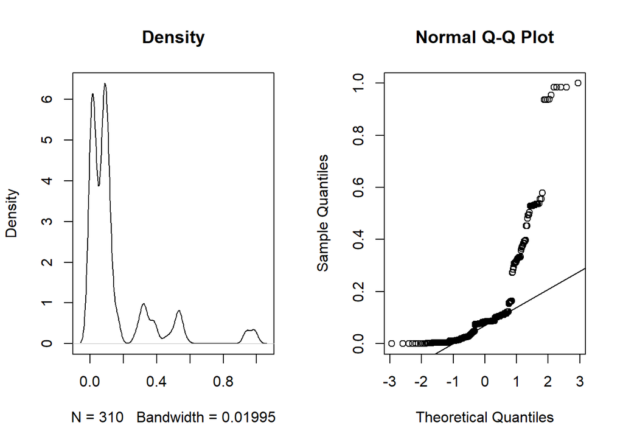

```r
par(mfrow=c(1,2))
plot(density(recursos_tec_df$Operation_theatres_in_hospital_norm) ,main="Density")
qqnorm(recursos_tec_df$Operation_theatres_in_hospital_norm)
qqline(recursos_tec_df$Operation_theatres_in_hospital_norm)
```

Para estudiar si una muestra proviene de una población con distribución normal, se disponen de tres herramientas:

- Histograma o Densidad
- Gráficos cuantil cuantil (QQplot)
- Pruebas de hipótesis.

Si en la prueba de Densidad se observa sesgo hacia uno de los lados de la gráfica, sería indicio de que la muestra no proviene de una población normal.Si por otra parte, sí se observa simetría, **NO** se garantiza que la muestra provenga de una población normal. En estos casos sería necesario utilizar otras herramientas como **QQplot y pruebas de hipótesis**.

En la gráfica Densidad de la variable “Operation_theatres_in_hospital_norm”, se observa claramente sesgo hacia la izquierda, por lo que no se considera normalidad. Se puede confirmar observando la gráfica QQplot en la que la línea que grafica qqline sirve de referencia para interpretar el gráfico. Si se tuviese una muestra distribuída normalmente, se esperaría que los puntos del gráfico quantil quantil estuviesen perfectamente alineados con la línea de referencia, y observamos que para este caso, “Operation_theatres_in_hospital_norm” no se alinea. Confirmaría los resultados del gráfico de densidad.

Por otro lado, se realizan las pruebas de hipótesis:

- $h_0: La muestra proviene de una población normal.
- $h_1: La muestra NO proviene de una población normal.

Se aplica la prueba Shapiro-Wilk:

```r
shapiro.test(recursos_tec_df$Operation_theatres_in_hospital_norm)
```

```
##
##  Shapiro-Wilk normality test
##
## data:  recursos_tec_df$Operation_theatres_in_hospital_norm
## W = 0.65768, p-value < 2.2e-16
```

Se observa un p-value muy pequeño, mucho más pequeño que cualquier nivel de significación ($alpha$=0.5) por lo que se rechaza la hipótesis nula y asumimos **No normalidad** en la muestra.

**SALAS DE CIRUGÍA**

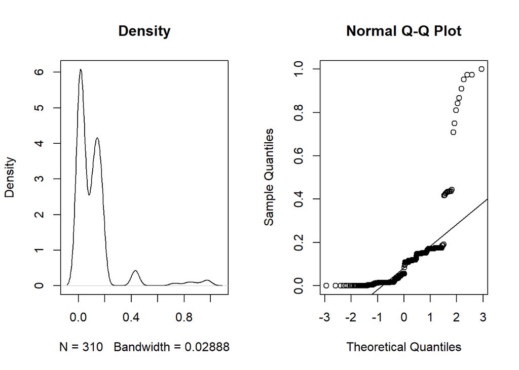

```r
par(mfrow=c(1,2))
plot(density(recursos_tec_df$Surgical_day_care_places_norm) ,main="Density")
qqnorm(recursos_tec_df$Surgical_day_care_places_norm)
qqline(recursos_tec_df$Surgical_day_care_places_norm)
```

En la gráfica Densidad de la variable “Surgical_day_care_places_norm” , se observa claramente sesgo hacia la izquierda, por lo que no se considera normalidad. Se puede confirmar observando la gráfica QQplot en la que la línea que grafica qqline sirve de referencia para interpretar el gráfico, no se alinea con los puntos de los valores de la variable “Surgical_day_care_places_norm”.

Tras aplicar la prueba Shapiro-Wilk:

```r
shapiro.test(recursos_tec_df$Surgical_day_care_places_norm)
```

```
##
##  Shapiro-Wilk normality test
##
## data:  recursos_tec_df$Surgical_day_care_places_norm
## W = 0.58393, p-value < 2.2e-16
```

Se observa un p-value muy pequeño, mucho más pequeño que cualquier nivel de significación ($alpha$=0.5) por lo que se rechaza la hipótesis nula y asumimos **No normalidad** en la muestra.

**SALAS PSIQUIÁTRICAS**

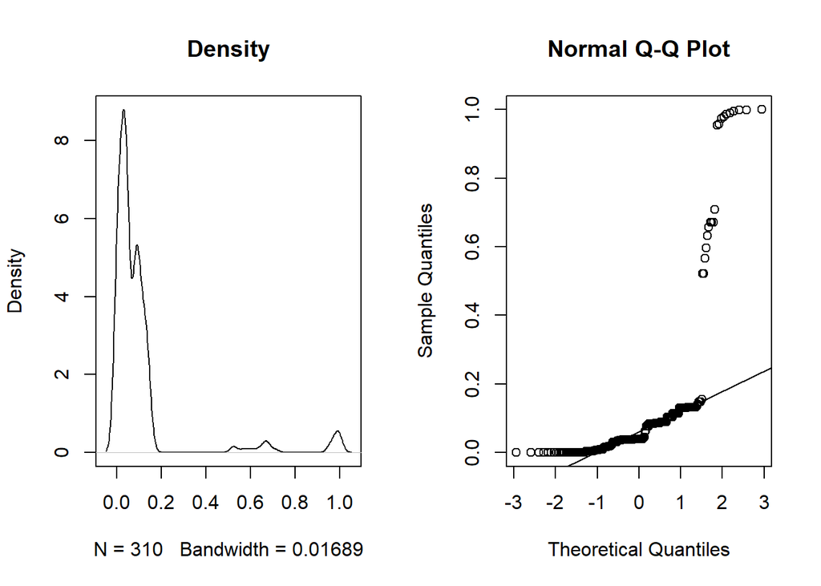

```r
par(mfrow=c(1,2))
plot(density(recursos_tec_df$Psychiatric_day_care_place_norm) ,main="Density")
qqnorm(recursos_tec_df$Psychiatric_day_care_place_norm)
qqline(recursos_tec_df$Psychiatric_day_care_place_norm)
```

En la gráfica Densidad de la variable “Psychiatric_day_care_place_norm” , se observa claramente sesgo hacia la izquierda, por lo que no se considera normalidad. Se puede confirmar observando la gráfica QQplot en la que la línea que grafica qqline sirve de referencia para interpretar el gráfico, no se alinea con los puntos de los valores de la variable “Psychiatric_day_care_place_norm”.

Tras aplicar la prueba Shapiro-Wilk:

```r
shapiro.test(recursos_tec_df$Psychiatric_day_care_place_norm)
```

```
##
##  Shapiro-Wilk normality test
##
## data:  recursos_tec_df$Psychiatric_day_care_place_norm
## W = 0.45965, p-value < 2.2e-16
```

Se observa un p-value muy pequeño, mucho más pequeño que cualquier nivel de significación ($alpha$=0.5) por lo que se rechaza la hipótesis nula y asumimos **No normalidad** en la muestra.

**CONSULTAS ONCOLÓGICAS**

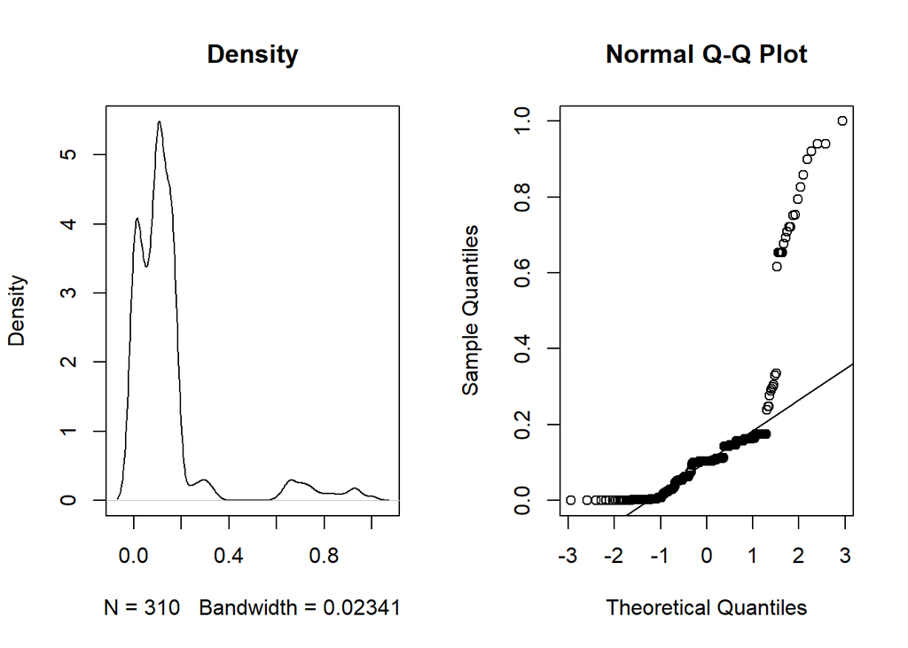

```r
par(mfrow=c(1,2))
plot(density(recursos_tec_df$Oncological_day_care_place_norm) ,main="Density")
qqnorm(recursos_tec_df$Oncological_day_care_place_norm)
qqline(recursos_tec_df$Oncological_day_care_place_norm)
```

En la gráfica Densidad de la variable “Oncological_day_care_place_norm” , se observa claramente sesgo hacia la izquierda, por lo que no se considera normalidad. Se puede confirmar observando la gráfica QQplot en la que la línea que grafica qqline sirve de referencia para interpretar el gráfico, no se alinea con los puntos de los valores de la variable “Oncological_day_care_place_norm”.

Tras aplicar la prueba Shapiro-Wilk:

```r
shapiro.test(recursos_tec_df$Oncological_day_care_place_norm)
```

```
##
##  Shapiro-Wilk normality test
##
## data:  recursos_tec_df$Oncological_day_care_place_norm
## W = 0.60077, p-value < 2.2e-16
```

Se observa un p-value muy pequeño, mucho más pequeño que cualquier nivel de significación ($alpha$=0.5) por lo que se rechaza la hipótesis nula y asumimos **No normalidad** en la muestra.

**CONSULTAS GERIÁTRICAS**

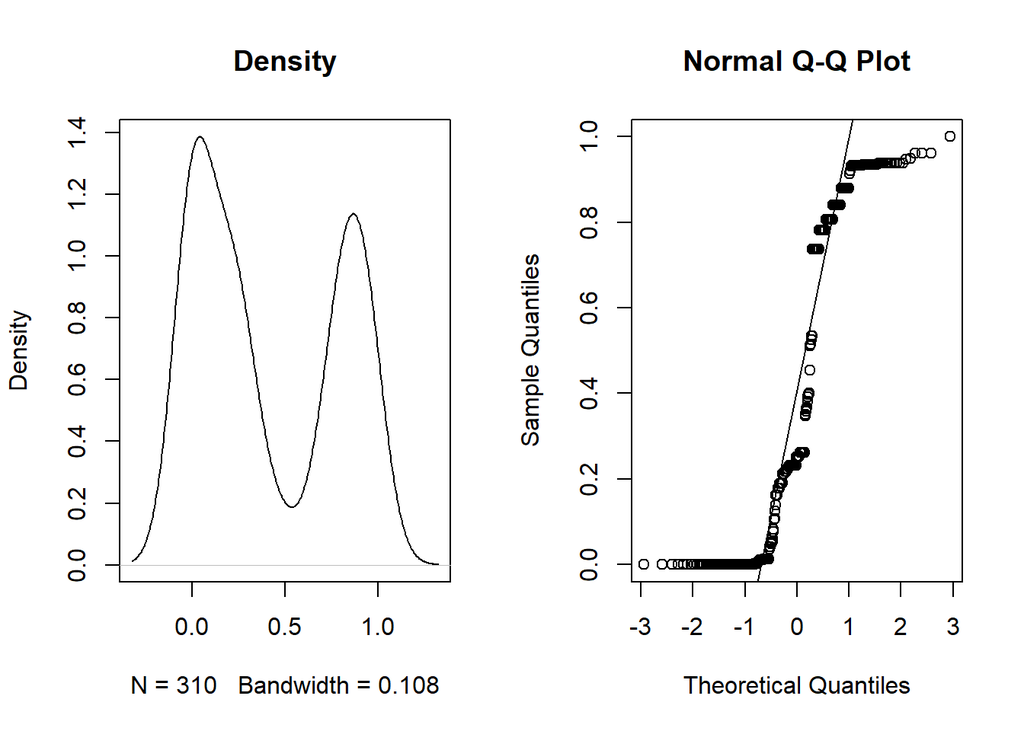

```r
par(mfrow=c(1,2))
plot(density(recursos_tec_df$Geriatric_day_care_places_norm) ,main="Density")
qqnorm(recursos_tec_df$Geriatric_day_care_places_norm)
qqline(recursos_tec_df$Geriatric_day_care_places_norm)
```

Tras aplicar la prueba Shapiro-Wilk:

```r
shapiro.test(recursos_tec_df$Geriatric_day_care_places_norm)
```

```
##
##  Shapiro-Wilk normality test
##
## data:  recursos_tec_df$Geriatric_day_care_places_norm
## W = 0.81538, p-value < 2.2e-16
```

Se observa un p-value muy pequeño, mucho más pequeño que cualquier nivel de significación ($alpha$=0.5) por lo que se rechaza la hipótesis nula y asumimos **No normalidad** en la muestra.

**ESCÁNERS**

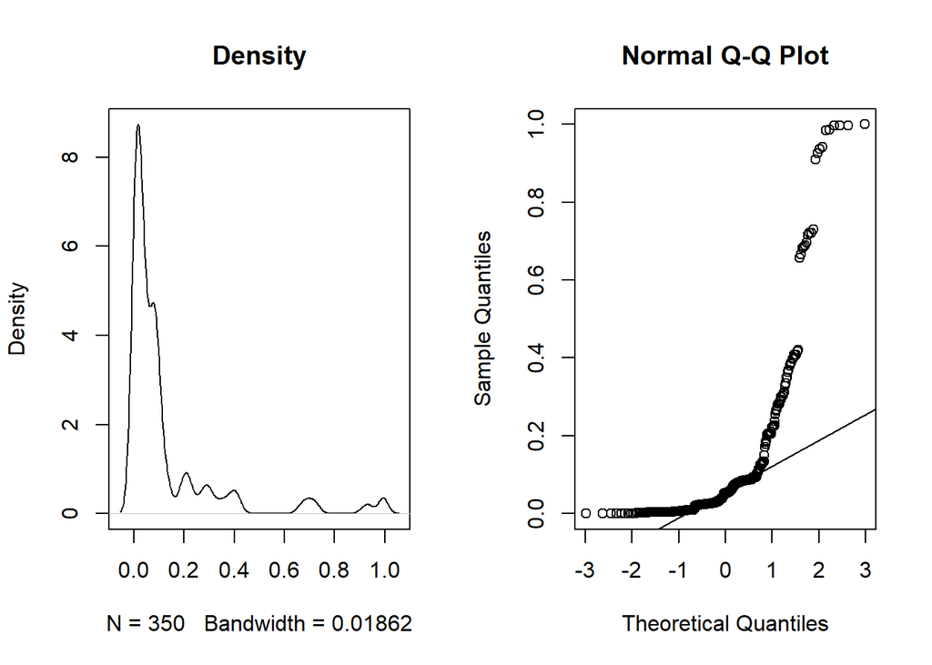

```r
par(mfrow=c(1,2))
plot(density(tecnologia_medica_df$Computed_Tomography_Scanners_norm) ,main="Density")
qqnorm(tecnologia_medica_df$Computed_Tomography_Scanners_norm)
qqline(tecnologia_medica_df$Computed_Tomography_Scanners_norm)
```

En la gráfica Densidad de la variable “Computed_Tomography_Scanners_norm” , se observa claramente sesgo hacia la izquierda, por lo que no se considera normalidad. Se puede confirmar observando la gráfica QQplot en la que la línea que grafica qqline sirve de referencia para interpretar el gráfico, no se alinea con los puntos de los valores de la variable “Computed_Tomography_Scanners_norm”.

Tras aplicar la prueba Shapiro-Wilk:

```r
shapiro.test(tecnologia_medica_df$Computed_Tomography_Scanners_norm)
```

```
##
##  Shapiro-Wilk normality test
##
## data:  tecnologia_medica_df$Computed_Tomography_Scanners_norm
## W = 0.59363, p-value < 2.2e-16
```

Se observa un p-value muy pequeño, mucho más pequeño que cualquier nivel de significación ($alpha$=0.5) por lo que se rechaza la hipótesis nula y asumimos **No normalidad** en la muestra.

**CÁMARAS GAMMA**

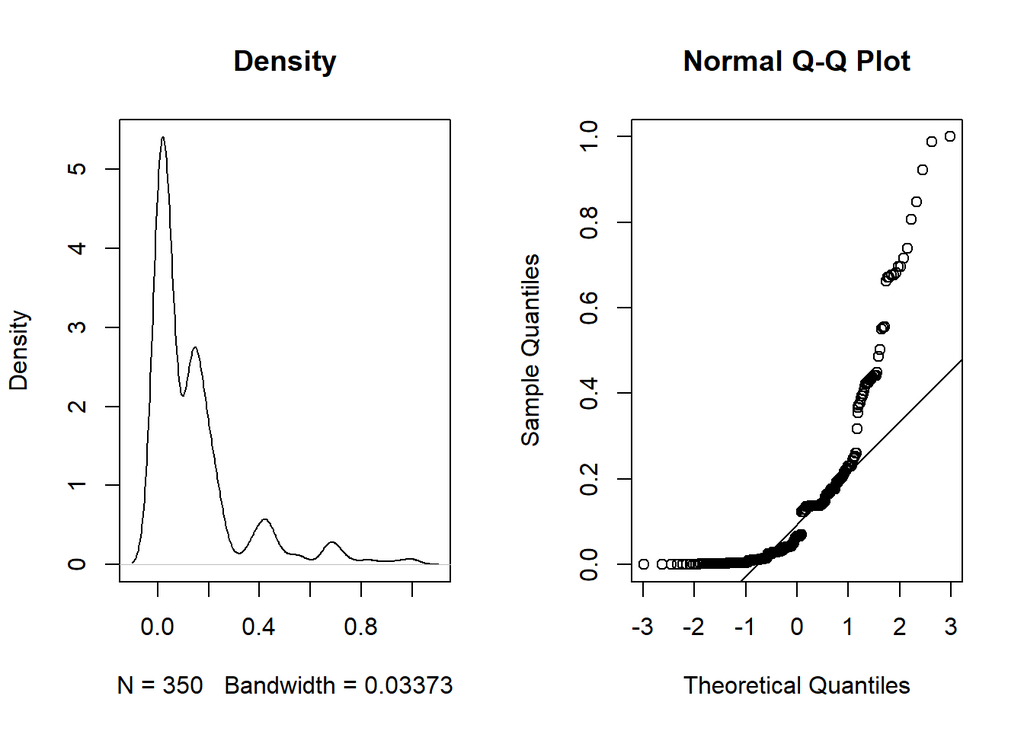

```r
par(mfrow=c(1,2))
plot(density(tecnologia_medica_df$Gamma_cameras_norm) ,main="Density")
qqnorm(tecnologia_medica_df$Gamma_cameras_norm)
qqline(tecnologia_medica_df$Gamma_cameras_norm)
```

En la gráfica Densidad de la variable “Gamma_cameras_norm” , se observa claramente sesgo hacia la izquierda, por lo que no se considera normalidad. Se puede confirmar observando la gráfica QQplot en la que la línea que grafica qqline sirve de referencia para interpretar el gráfico, no se alinea con los puntos de los valores de la variable “Gamma_cameras_norm”.

Tras aplicar la prueba Shapiro-Wilk:

```r
shapiro.test(tecnologia_medica_df$Gamma_cameras_norm)
```

```
##
##  Shapiro-Wilk normality test
##
## data:  tecnologia_medica_df$Gamma_cameras_norm
## W = 0.71992, p-value < 2.2e-16
```

Se observa un p-value muy pequeño, mucho más pequeño que cualquier nivel de significación ($alpha$=0.5) por lo que se rechaza la hipótesis nula y asumimos **No normalidad** en la muestra.

**LITOTRIPTORES**

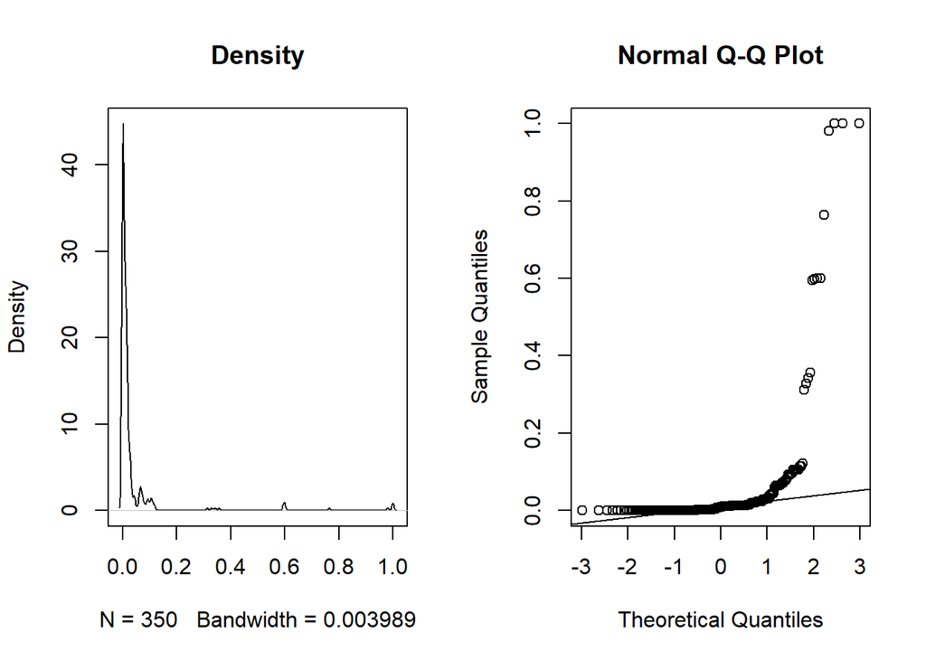

```r
par(mfrow=c(1,2))
plot(density(tecnologia_medica_df$Lithotriptors_norm) ,main="Density")
qqnorm(tecnologia_medica_df$Lithotriptors_norm)
qqline(tecnologia_medica_df$Lithotriptors_norm)
```

En la gráfica Densidad de la variable “Lithotriptors_norm” , se observa claramente sesgo hacia la izquierda, por lo que no se considera normalidad. Se puede confirmar observando la gráfica QQplot en la que la línea que grafica qqline sirve de referencia para interpretar el gráfico, no se alinea con los puntos de los valores de la variable “Lithotriptors_norm”.

Tras aplicar la prueba Shapiro-Wilk:

```r
shapiro.test(tecnologia_medica_df$Lithotriptors_norm)
```

```
##
##  Shapiro-Wilk normality test
##
## data:  tecnologia_medica_df$Lithotriptors_norm
## W = 0.2844, p-value < 2.2e-16
```

Se observa un p-value muy pequeño, mucho más pequeño que cualquier nivel de significación ($alpha$=0.5) por lo que se rechaza la hipótesis nula y asumimos **No normalidad** en la muestra.

**UNIDADES DE RESONANCIA MAGNÉTICA**

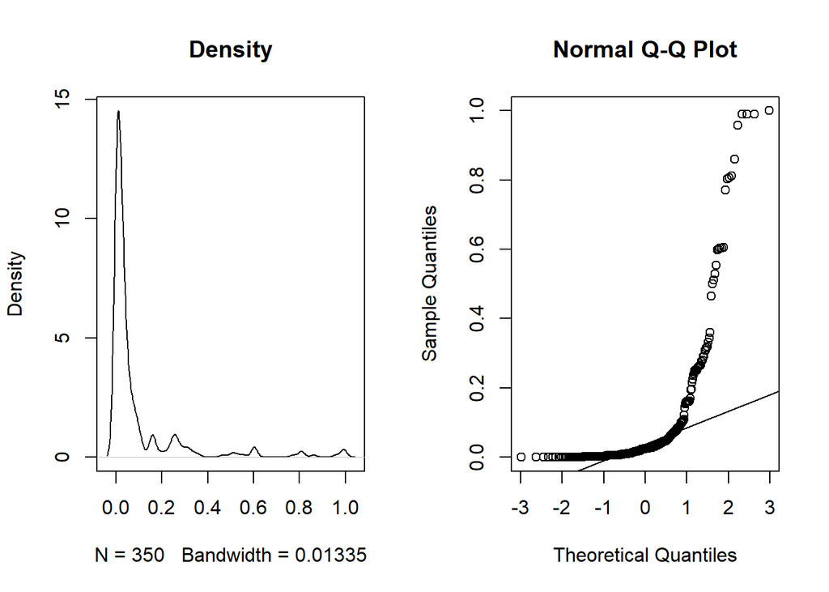

```r
par(mfrow=c(1,2))
plot(density(tecnologia_medica_df$Magnetic_Resonance_Imaging_Units_norm) ,main="Density")
qqnorm(tecnologia_medica_df$Magnetic_Resonance_Imaging_Units_norm)
qqline(tecnologia_medica_df$Magnetic_Resonance_Imaging_Units_norm)
```

En la gráfica Densidad de la variable “Magnetic_Resonance_Imaging_Units” , se observa claramente sesgo hacia la izquierda, por lo que no se considera normalidad. Se puede confirmar observando la gráfica QQplot en la que la línea que grafica qqline sirve de referencia para interpretar el gráfico, no se alinea con los puntos de los valores de la variable “Magnetic_Resonance_Imaging_Units”.

Tras aplicar la prueba Shapiro-Wilk:

```r
shapiro.test(tecnologia_medica_df$Magnetic_Resonance_Imaging_Units_norm)
```

```
##
##  Shapiro-Wilk normality test
##
## data:  tecnologia_medica_df$Magnetic_Resonance_Imaging_Units_norm
## W = 0.51976, p-value < 2.2e-16
```

Se observa un p-value muy pequeño, mucho más pequeño que cualquier nivel de significación ($alpha$=0.5) por lo que se rechaza la hipótesis nula y asumimos **No normalidad** en la muestra.

**UNIDADES DE ANGIOGRAFÍA**

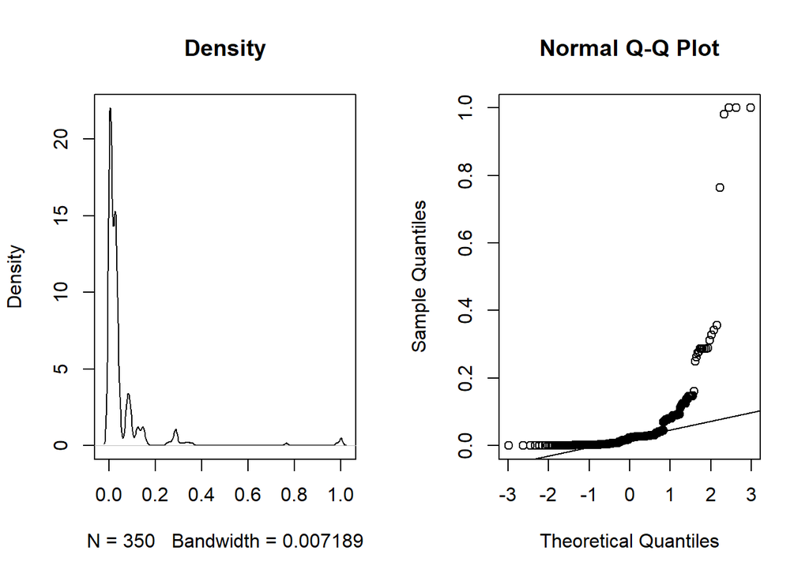

```r
par(mfrow=c(1,2))
plot(density(tecnologia_medica_df$Angiography_units_norm) ,main="Density")
qqnorm(tecnologia_medica_df$Angiography_units_norm)
qqline(tecnologia_medica_df$Angiography_units_norm)
```

En la gráfica Densidad de la variable “Angiography_units” , se observa claramente sesgo hacia la izquierda, por lo que no se considera normalidad. Se puede confirmar observando la gráfica QQplot en la que la línea que grafica qqline sirve de referencia para interpretar el gráfico, no se alinea con los puntos de los valores de la variable “Angiography_units”.

Tras aplicar la prueba Shapiro-Wilk:

```r
shapiro.test(tecnologia_medica_df$Angiography_units_norm)
```

```
##
##  Shapiro-Wilk normality test
##
## data:  tecnologia_medica_df$Angiography_units_norm
## W = 0.38649, p-value < 2.2e-16
```

Se observa un p-value muy pequeño, mucho más pequeño que cualquier nivel de significación ($alpha$=0.5) por lo que se rechaza la hipótesis nula y asumimos **No normalidad** en la muestra.

**CAMAS DISPONIBLES**

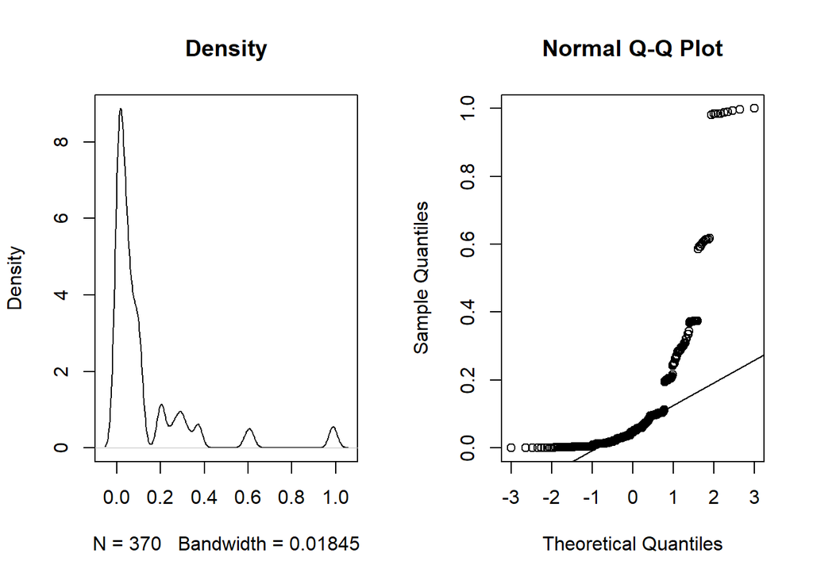

```r
par(mfrow=c(1,2))
plot(density(camas_disponibles_df$Value_norm) ,main="Density")
qqnorm(camas_disponibles_df$Value_norm)
qqline(camas_disponibles_df$Value_norm)
```

En la gráfica Densidad de la variable “Value_norm” , se observa claramente sesgo hacia la izquierda, por lo que no se considera normalidad. Se puede confirmar observando la gráfica QQplot en la que la línea que grafica qqline sirve de referencia para interpretar el gráfico, no se alinea con los puntos de los valores de la variable “Value_norm”.

Tras aplicar la prueba Shapiro-Wilk:

```r
shapiro.test(camas_disponibles_df$Value_norm)
```

```
##
##  Shapiro-Wilk normality test
##
## data:  camas_disponibles_df$Value_norm
## W = 0.59891, p-value < 2.2e-16
```

Se observa un p-value muy pequeño, mucho más pequeño que cualquier nivel de significación ($alpha$=0.5) por lo que se rechaza la hipótesis nula y asumimos **No normalidad** en la muestra.